# **Data Exploration: Cyber Security Case Study**

## **Dataset Information:**

The NF-CSE-CIC-IDS2018.csv dataset is a NetFlow-based dataset generated from the original pcap files (CSE-CIC-IDS2018). The total number of flows is 8,392,401 out of which 1,019,203 (12.14%) are attack samples and 7,373,198 (87.86%) are benign ones.

The architecture of the used network was immensely expanded, as it contained three servers, ten computers (Windows, Linux and Mac) and a firewall.

Source: https://staff.itee.uq.edu.au/marius/NIDS_datasets/#RA4

Attributes are:

- IPV4_SRC_ADDR - IPv4 source address
- IPV4_DST_ADDR - IPv4 destination address
- L4_SRC_PORT - IPv4 source port number
- L4_DST_PORT - IPv4 destination port number
- PROTOCOL - IP protocol identifier byte
- TCP_FLAGS - Cumulative of all TCP flags
- L7_PROTO - Layer 7 protocol (numeric)
- IN_BYTES - Incoming number of bytes
- OUT_BYTES - Outgoing number of bytes
- IN_PKTS - Incoming number of packets
- OUT_PKTS - Outgoing number of packets
- FLOW_DURATION_MILLISECONDS - Flow duration in milliseconds
- LABEL - Intrusion or not
- Attack - Type of attack

## **Step 1: Import and Inspect the Data**

```python
import pandas as pd

# Import data from CSV
df = pd.read_csv("data/NF-CSE-CIC-IDS2018.csv")

# Set display option to avoid scientific notation
pd.set_option('display.float_format', '{:.2f}'.format)

df.head(3)
```

|  | IPV4_SRC_ADDR | L4_SRC_PORT | IPV4_DST_ADDR | L4_DST_PORT | PROTOCOL | L7_PROTO | IN_BYTES | OUT_BYTES | IN_PKTS | OUT_PKTS | TCP_FLAGS | FLOW_DURATION_MILLISECONDS | Label | Attack |
| --- | --- | --- | --- | --- | --- | --- | --- | --- | --- | --- | --- | --- | --- | --- |
| 0 | 172.31.66.17 | 51128 | 23.36.69.189 | 443 | 6 | 91.00 | 152 | 0 | 3 | 0 | 194 | 4285680 | 0 | Benign |
| 1 | 34.195.59.178 | 443 | 172.31.66.17 | 51036 | 6 | 91.18 | 994 | 979 | 7 | 7 | 24 | 4234714 | 0 | Benign |
| 2 | 112.215.171.212 | 12262 | 172.31.66.17 | 445 | 6 | 0.00 | 585 | 344 | 5 | 4 | 30 | 4294106 | 0 | Benign |

This dataset contains 8,392,401 rows and 14 columns.

```python
df.shape
```

```
(8392401, 14)
```

This dataset also contains 3 categorical (object: character/string) and 11 numerical (integers, float).

```python
df.info()
```

```
<class 'pandas.core.frame.DataFrame'>
RangeIndex: 8392401 entries, 0 to 8392400
Data columns (total 14 columns):
 #   Column                      Dtype
---  ------                      -----
 0   IPV4_SRC_ADDR               object
 1   L4_SRC_PORT                 int64
 2   IPV4_DST_ADDR               object
 3   L4_DST_PORT                 int64
 4   PROTOCOL                    int64
 5   L7_PROTO                    float64
 6   IN_BYTES                    int64
 7   OUT_BYTES                   int64
 8   IN_PKTS                     int64
 9   OUT_PKTS                    int64
 10  TCP_FLAGS                   int64
 11  FLOW_DURATION_MILLISECONDS  int64
 12  Label                       int64
 13  Attack                      object
dtypes: float64(1), int64(10), object(3)
memory usage: 896.4+ MB
```

```python
# Summary of statistics of numerical data
df.describe()
```

|  | L4_SRC_PORT | L4_DST_PORT | PROTOCOL | L7_PROTO | IN_BYTES | OUT_BYTES | IN_PKTS | OUT_PKTS | TCP_FLAGS | FLOW_DURATION_MILLISECONDS | Label |
| --- | --- | --- | --- | --- | --- | --- | --- | --- | --- | --- | --- |
| count | 8392401.00 | 8392401.00 | 8392401.00 | 8392401.00 | 8392401.00 | 8392401.00 | 8392401.00 | 8392401.00 | 8392401.00 | 8392401.00 | 8392401.00 |
| mean | 42523.88 | 8406.35 | 8.85 | 19.06 | 3761.34 | 4346.90 | 39.42 | 5.90 | 64.09 | 2832315.41 | 0.12 |
| std | 22012.60 | 17572.72 | 5.00 | 35.65 | 130629.81 | 257957.77 | 1948.31 | 177.25 | 89.05 | 2030249.85 | 0.33 |
| min | 0.00 | 0.00 | 0.00 | 0.00 | 0.00 | 0.00 | 0.00 | 0.00 | 0.00 | 0.00 | 0.00 |
| 25% | 37268.00 | 53.00 | 6.00 | 0.00 | 65.00 | 0.00 | 1.00 | 0.00 | 0.00 | 0.00 | 0.00 |
| 50% | 51643.00 | 443.00 | 6.00 | 0.00 | 153.00 | 120.00 | 3.00 | 1.00 | 24.00 | 4291835.00 | 0.00 |
| 75% | 56746.00 | 3389.00 | 17.00 | 7.00 | 1360.00 | 700.00 | 8.00 | 6.00 | 31.00 | 4294906.00 | 0.00 |
| max | 65535.00 | 65535.00 | 58.00 | 248.00 | 24371270.00 | 214122854.00 | 279963.00 | 142798.00 | 223.00 | 4294967.00 | 1.00 |

```python
# Summary of statistics of categorical data
df.describe(include=['object'])
```

|  | IPV4_SRC_ADDR | IPV4_DST_ADDR | Attack |
| --- | --- | --- | --- |
| count | 8392401 | 8392401 | 8392401 |
| unique | 75405 | 26303 | 15 |
| top | 172.31.69.25 | 172.31.0.2 | Benign |
| freq | 840864 | 2045759 | 7373198 |

## **Step 2: Conversion of Variables**

**Categorical Data:**

- IPV4_SRC_ADDR - Nominal
- IPV4_DST_ADDR - Nominal
- L4_SRC_PORT - Nominal
- L4_DST_PORT - Nominal
- PROTOCOL - Nominal
- L7_PROTO - Nominal
- Label - Nominal
- Attack - Nominal

**Categorical Data Conversions:** Summary of Findings

- Convert object types into categorical data: **IPV4_SRC_ADDR, IPV4_DST_ADDR, Attack**
- Convert numerical column into categorical data: **L7_PROTO, PROTOCOL, Label, L4_SRC_PORT, L4_DST_PORT**
1. **IPV4_SRC_ADDR, IPV4_DST_ADDR, L4_SRC_PORT, L4_DST_PORT**

IP addresses help identify the source (where the data originates) and the destination (where it's going) of network traffic, while port numbers indicate specific services or applications involved in the communication (e.g., port 80 for HTTP, port 443 for HTTPS). However, their utility is closely tied to the infrastructure where the network traffic is captured. This means they are infrastructure-dependent and may be considered redundant. As a result, many research papers typically exclude these features from their machine learning models, and also due to their nature as high-cardinality categorical variables.

Some studies have explored novel methods to encode network addresses into low-dimensional embeddings using hash and embedding transformations. This approach could be worth exploring in future research. https://doi.org/10.1016/j.knosys.2021.106887

```python
# Convert objects to category type
df['IPV4_SRC_ADDR'] = df['IPV4_SRC_ADDR'].astype('category')
df['IPV4_DST_ADDR'] = df['IPV4_DST_ADDR'].astype('category')
```

```python
# Convert numerical to category type
df['L4_SRC_PORT'] = df['L4_SRC_PORT'].astype('category')
df['L4_DST_PORT'] = df['L4_DST_PORT'].astype('category')
```

2. **L7_PROTO**

The Layer 7 Protocol, often referred to as the Application Layer Protocol, is part of the OSI (Open Systems Interconnection) model, specifically at the top layer, Layer 7. This layer deals with the protocols and services that applications use to communicate over a network.

While the L7_PROTO might be assigned numerical values, these numbers are essentially labels or codes that represent different Layer 7 protocols (e.g., HTTP, FTP, DNS).

Reference: https://www.ntop.org/guides/nprobe/cli_options.html

```python
# Convert L7_PROTO to whole numbers and convert to category
df['L7_PROTO'] = df['L7_PROTO'].round(0).astype(int).astype('category')
```

3. **PROTOCOL**

An IP (Internet Protocol) Protocol is a set of rules governing how data is sent and received over a network, particularly the internet.

The IP protocol identifier byte is best treated as a categorical feature since each protocol number represents a distinct protocol (e.g., TCP, UDP, ICMP). These protocols have unique characteristics, behaviors, and security implications. Later on, separate binary features like is_TCP, is_UDP, is_ICMP, etc. can be created.

```python
df['PROTOCOL'] = df['PROTOCOL'].astype('category')
```

3. **Label**

The Label column is used to distinguish if there was an intrusion (1) or not (0).

```python
df['Label'] = df['Label'].astype('category')
```

4. **Attack** (Simplified)

The Attack column is used to distinguish the type of attack: Benign, DDoS, etc. These are the possible values:

- **Benign:** Refers to normal, non-malicious network traffic or activity that poses no threat. It is often used as a baseline or control in cybersecurity to distinguish from harmful activities.
- **DDoS (Distributed Denial of Service):** An attack where multiple compromised systems (often part of a botnet) flood a target (e.g., a server, website) with overwhelming traffic, causing disruption or complete denial of service.
- **BruteForce:** An attack that involves systematically trying all possible combinations of passwords or keys to gain unauthorized access to a system or account.
- **DoS (Denial of Service):** An attack that aims to make a network resource or service unavailable by overwhelming it with a flood of illegitimate requests, causing it to crash or slow down significantly.
- **Infiltration:** Unauthorized access or intrusion into a network or system, often to steal sensitive information or cause damage.
- **Bot:** A type of malware that allows an attacker to take control of an infected computer. Bots are often used to form botnets, large groups of compromised computers controlled remotely by an attacker.
- **Web Attacks:** Attacks targeting websites or web applications, often exploiting vulnerabilities in web technologies to steal data, manipulate content, or disrupt services.

```python
df['Attack'] = df['Attack'].astype('category')
```

```python
# Number of Attack labels
df['Attack'].value_counts()
```

```
Attack
Benign                      7373198
DDoS attacks-LOIC-HTTP       378199
FTP-BruteForce               193360
DoS attacks-Hulk             108136
DoS attacks-SlowHTTPTest     105550
SSH-Bruteforce                94237
Infilteration                 62072
DoS attacks-GoldenEye         32850
DoS attacks-Slowloris         22825
Bot                           15683
Brute Force -Web               2613
Brute Force -XSS               1745
DDOS attack-LOIC-UDP           1667
DDOS attack-HOIC                230
SQL Injection                    36
Name: count, dtype: int64
```

We can recategorize the types of attacks into fewer types: 7 in total as seen below.

```python
# Dictionary for renaming
rename_dict = {
    'Benign': 'Benign',
    'DDoS attacks-LOIC-HTTP': 'DDoS',
    'FTP-BruteForce': 'BruteForce',
    'DoS attacks-Hulk': 'DoS',
    'DoS attacks-SlowHTTPTest': 'DoS',
    'SSH-Bruteforce': 'BruteForce',
    'Infilteration': 'Infiltration',
    'DoS attacks-GoldenEye': 'DoS',
    'DoS attacks-Slowloris': 'DoS',
    'Bot': 'Bot',
    'Brute Force -Web': 'Web Attacks',
    'Brute Force -XSS': 'Web Attacks',
    'DDOS attack-LOIC-UDP': 'DDoS',
    'DDOS attack-HOIC': 'DDoS',
    'SQL Injection': 'Web Attacks'
}

# Add new column with simplified attack names
df['Attack_simplified'] = df['Attack'].map(rename_dict)

# Number of Attack labels after renaming
#df['Attack_simplified'].value_counts()
```

```python
# Convert to categorical
df['Attack_simplified'] = df['Attack_simplified'].astype('category')
```

Check the final output.

```python
df.describe(include=['category'])
```

|  | IPV4_SRC_ADDR | L4_SRC_PORT | IPV4_DST_ADDR | L4_DST_PORT | PROTOCOL | L7_PROTO | Label | Attack | Attack_simplified |
| --- | --- | --- | --- | --- | --- | --- | --- | --- | --- |
| count | 8392401 | 8392401 | 8392401 | 8392401 | 8392401 | 8392401 | 8392401 | 8392401 | 8392401 |
| unique | 75405 | 65010 | 26303 | 65092 | 7 | 87 | 2 | 15 | 7 |
| top | 172.31.69.25 | 80 | 172.31.0.2 | 53 | 6 | 0 | 0 | Benign | Benign |
| freq | 840864 | 454348 | 2045759 | 2047373 | 6171561 | 5499959 | 7373198 | 7373198 | 7373198 |

**Numerical Data:**

- TCP_FLAGS - Discrete
- IN_BYTES - Discrete
- OUT_BYTES - Discrete
- IN_PKTS - Discrete
- OUT_PKTS - Discrete
- FLOW_DURATION_MILLISECONDS - Continuous

**Numerical Data Conversions:** Summary of Findings

- Create new columns (may or may not be used lter): **IPV4_SRC_ADDR_num, IPV4_DST_ADDR_num**
- Retain as numerical: **TCP_FLAGS, IN_BYTES, OUT_BYTES, IN_PKTS, OUT_PKTS, FLOW_DURATION_MILLISECONDS**
1. **IPV4_SRC_ADDR and IPV4_DST_ADDR**

IPv4 source and destination addresses are typically considered categorical data, despite being represented numerically (e.g., 192.168.0.1). For the purpose of feeding them into machine learning models later on, I will create new columns to store their numerical representations.

```python
import ipaddress

def ip_to_int(ip_str):
    """Converts an IPv4 address in dotted-decimal notation to an integer."""
    try:
        ip_obj = ipaddress.IPv4Address(ip_str)
        return int(ip_obj)
    except ValueError:
        # Handle invalid IP addresses (e.g., return a default value or raise an error)
        return 0  # or raise ValueError(f"Invalid IP address: {ip_str}")

# Convert IP addresses to integers
df['IPV4_SRC_ADDR_num'] = df['IPV4_SRC_ADDR'].apply(ip_to_int)
df['IPV4_DST_ADDR_num'] = df['IPV4_DST_ADDR'].apply(ip_to_int)
```

2. **TCP_FLAGS** (No conversion)

The TCP Flags is a cumulative of all the TCP flags seen for this flow (e.g., SYN, ACK, FIN, RST). It represents a cumulative value obtained by performing a bitwise OR operation on the individual TCP flags observed during a flow. Each flag corresponds to a specific bit in a byte, and the cumulative value is the sum of the decimal representations of these active flags.

- Sample: SYN + ACK + PSH + FIN = 2 + 16 + 8 + 1 = 27
- Reference: https://www.manitonetworks.com/flow-management/2016/10/16/decoding-tcp-flags

```python
#df['TCP_FLAGS'] = df['TCP_FLAGS'].astype('category')
```

Check the final output.

```python
df.describe()
```

|  | IN_BYTES | OUT_BYTES | IN_PKTS | OUT_PKTS | TCP_FLAGS | FLOW_DURATION_MILLISECONDS | IPV4_SRC_ADDR_num | IPV4_DST_ADDR_num |
| --- | --- | --- | --- | --- | --- | --- | --- | --- |
| count | 8392401.00 | 8392401.00 | 8392401.00 | 8392401.00 | 8392401.00 | 8392401.00 | 8392401.00 | 8392401.00 |
| mean | 3761.34 | 4346.90 | 39.42 | 5.90 | 64.09 | 2832315.41 | 2420840111.71 | 2429555921.79 |
| std | 130629.81 | 257957.77 | 1948.31 | 177.25 | 89.05 | 2030249.85 | 1033896267.74 | 1028442421.06 |
| min | 0.00 | 0.00 | 0.00 | 0.00 | 0.00 | 0.00 | 0.00 | 0.00 |
| 25% | 65.00 | 0.00 | 1.00 | 0.00 | 0.00 | 0.00 | 2887729159.00 | 2852039166.00 |
| 50% | 153.00 | 120.00 | 3.00 | 1.00 | 24.00 | 4291835.00 | 2887729684.00 | 2887712770.00 |
| 75% | 1360.00 | 700.00 | 8.00 | 6.00 | 31.00 | 4294906.00 | 2887730440.00 | 2887730438.00 |
| max | 24371270.00 | 214122854.00 | 279963.00 | 142798.00 | 223.00 | 4294967.00 | 3758093511.00 | 4294967295.00 |

## **Step 3: Data Accuracy Check: Missing values, duplications, outliers (using univariate method)**

### **1) Handling Missing Data**

There are no missing values.

```python
df.isnull().sum()
```

```
IPV4_SRC_ADDR                 0
L4_SRC_PORT                   0
IPV4_DST_ADDR                 0
L4_DST_PORT                   0
PROTOCOL                      0
L7_PROTO                      0
IN_BYTES                      0
OUT_BYTES                     0
IN_PKTS                       0
OUT_PKTS                      0
TCP_FLAGS                     0
FLOW_DURATION_MILLISECONDS    0
Label                         0
Attack                        0
Attack_simplified             0
IPV4_SRC_ADDR_num             0
IPV4_DST_ADDR_num             0
dtype: int64
```

### **2) Handling Duplicated Data**

```python
# Count number of duplicate rows
df.duplicated(keep=False).sum()
```

```
1463859
```

```python
# Remove duplicated rows
df.drop_duplicates(inplace=True)
```

```python
# Count number of duplicate rows (after deletion)
df.duplicated(keep=False).sum()
```

```
0
```

### **3) Handling Invalid / Out-of-Range Values**

**Valid ranges:**

- **Categorical**:
  - IPV4_SRC_ADDR - 0.0.0.0 to 255.255.255.255
  - IPV4_DST_ADDR - 0.0.0.0 to 255.255.255.255
  - L4_SRC_PORT - 1 to 65535
  - L4_DST_PORT - 1 to 65535
  - PROTOCOL - 0 to 255
  - L7_PROTO - 0 to 421
  - Label - 0 or 1
  - Attack - simplified below:
    - Benign
    - Bot
    - BruteForce
    - DDoS
    - DoS
    - Infiltration
    - Web Attacks
- **Numerical**:
  - IN_BYTES - 0 or greater
  - OUT_BYTES - 0 or greater
  - IN_PKTS - 0 or greater
  - OUT_PKTS - 0 or greater
  - TCP_FLAGS - 0 (no flags set) to 255 (all flags set)
  - FLOW_DURATION_MILLISECONDS - 0 or greater

Remove out of range **IPv4 addresses**: 2 rows found.

```python
# Function to validate IP addresses
def is_valid_ipv4(ip):
    try:
        ipaddress.IPv4Address(ip)
        return True
    except ipaddress.AddressValueError:
        return False

# Filter and display rows with invalid IP addresses
df[~df['IPV4_SRC_ADDR'].apply(is_valid_ipv4) | ~df['IPV4_DST_ADDR'].apply(is_valid_ipv4)]
```

|  | IPV4_SRC_ADDR | L4_SRC_PORT | IPV4_DST_ADDR | L4_DST_PORT | PROTOCOL | L7_PROTO | IN_BYTES | OUT_BYTES | IN_PKTS | OUT_PKTS | TCP_FLAGS | FLOW_DURATION_MILLISECONDS | Label | Attack | Attack_simplified | IPV4_SRC_ADDR_num | IPV4_DST_ADDR_num |
| --- | --- | --- | --- | --- | --- | --- | --- | --- | --- | --- | --- | --- | --- | --- | --- | --- | --- |
| 1844166 | 0 | 0 | 0 | 0 | 0 | 0 | 0 | 0 | 0 | 0 | 0 | 0 | 0 | Benign | Benign | 0 | 0 |
| 7795209 | 172.31.69.25 | 0 | 188. | 0 | 0 | 0 | 0 | 0 | 0 | 0 | 0 | 0 | 0 | Benign | Benign | 2887730457 | 0 |

```python
# Count before deletion
df.shape
```

```
(7314622, 17)
```

```python
# Delete invalid rows from the DataFrame
df = df[df['IPV4_SRC_ADDR'].apply(is_valid_ipv4) & df['IPV4_DST_ADDR'].apply(is_valid_ipv4)]

# Count after deletion
df.shape
```

```
(7314620, 17)
```

```python
# Check out of range ports (source port)
df[~df['L4_SRC_PORT'].isin(range(1, 65536))].shape[0]
```

```
17697
```

```python
# Count before deletion
df.shape
```

```
(7314620, 17)
```

```python
# Delete invalid rows from the DataFrame
df = df[df['L4_SRC_PORT'].isin(range(1, 65536))]

# Count after deletion
df.shape
```

```
(7296923, 17)
```

```python
# Check out of range ports (destination port)
df[~df['L4_DST_PORT'].isin(range(1, 65536))]
```

|  | IPV4_SRC_ADDR | L4_SRC_PORT | IPV4_DST_ADDR | L4_DST_PORT | PROTOCOL | L7_PROTO | IN_BYTES | OUT_BYTES | IN_PKTS | OUT_PKTS | TCP_FLAGS | FLOW_DURATION_MILLISECONDS | Label | Attack | Attack_simplified | IPV4_SRC_ADDR_num | IPV4_DST_ADDR_num |
| --- | --- | --- | --- | --- | --- | --- | --- | --- | --- | --- | --- | --- | --- | --- | --- | --- | --- |
| 2252676 | 77.72.85.27 | 45365 | 172.31.67.61 | 0 | 6 | 0 | 40 | 0 | 1 | 0 | 2 | 0 | 0 | Benign | Benign | 1296586011 | 2887729981 |

```python
# Delete invalid rows from the DataFrame
df = df[df['L4_DST_PORT'].isin(range(1, 65536))]

# Count after deletion
df.shape
```

```
(7296922, 17)
```

```python
df['PROTOCOL'].value_counts()
```

```
PROTOCOL
6     5177681
17    2119241
0           0
1           0
2           0
47          0
58          0
Name: count, dtype: int64
```

Remove out of range **PROTOCOL**: None found.

```python
# Filter and display rows with invalid protocol numbers
df[~df['PROTOCOL'].isin(range(0, 256))]
```

|  | IPV4_SRC_ADDR | L4_SRC_PORT | IPV4_DST_ADDR | L4_DST_PORT | PROTOCOL | L7_PROTO | IN_BYTES | OUT_BYTES | IN_PKTS | OUT_PKTS | TCP_FLAGS | FLOW_DURATION_MILLISECONDS | Label | Attack | Attack_simplified | IPV4_SRC_ADDR_num | IPV4_DST_ADDR_num |
| --- | --- | --- | --- | --- | --- | --- | --- | --- | --- | --- | --- | --- | --- | --- | --- | --- | --- |

Remove out of range **TCP_FLAGS**: None found.

```python
df[~df['TCP_FLAGS'].isin(range(0, 256))]
```

|  | IPV4_SRC_ADDR | L4_SRC_PORT | IPV4_DST_ADDR | L4_DST_PORT | PROTOCOL | L7_PROTO | IN_BYTES | OUT_BYTES | IN_PKTS | OUT_PKTS | TCP_FLAGS | FLOW_DURATION_MILLISECONDS | Label | Attack | Attack_simplified | IPV4_SRC_ADDR_num | IPV4_DST_ADDR_num |
| --- | --- | --- | --- | --- | --- | --- | --- | --- | --- | --- | --- | --- | --- | --- | --- | --- | --- |

Remove out of range **L7_PROTO**: None found.

- Note: While a value of 0 signifies an unidentified protocol, it is still a valid entry within nProbe's reporting.

```python
df[~df['L7_PROTO'].isin(range(0, 422))]
```

|  | IPV4_SRC_ADDR | L4_SRC_PORT | IPV4_DST_ADDR | L4_DST_PORT | PROTOCOL | L7_PROTO | IN_BYTES | OUT_BYTES | IN_PKTS | OUT_PKTS | TCP_FLAGS | FLOW_DURATION_MILLISECONDS | Label | Attack | Attack_simplified | IPV4_SRC_ADDR_num | IPV4_DST_ADDR_num |
| --- | --- | --- | --- | --- | --- | --- | --- | --- | --- | --- | --- | --- | --- | --- | --- | --- | --- |

Remove out of range **Label**: None found.

```python
df[~df['Label'].isin(range(0, 2))]
```

|  | IPV4_SRC_ADDR | L4_SRC_PORT | IPV4_DST_ADDR | L4_DST_PORT | PROTOCOL | L7_PROTO | IN_BYTES | OUT_BYTES | IN_PKTS | OUT_PKTS | TCP_FLAGS | FLOW_DURATION_MILLISECONDS | Label | Attack | Attack_simplified | IPV4_SRC_ADDR_num | IPV4_DST_ADDR_num |
| --- | --- | --- | --- | --- | --- | --- | --- | --- | --- | --- | --- | --- | --- | --- | --- | --- | --- |

Remove out of range **Attack**: None found.

```python
attack_types = ['Benign', 'DDoS', 'DoS', 'BruteForce', 'Infiltration', 'Bot', 'Web Attacks']
df[~df['Attack_simplified'].isin(attack_types)]
```

|  | IPV4_SRC_ADDR | L4_SRC_PORT | IPV4_DST_ADDR | L4_DST_PORT | PROTOCOL | L7_PROTO | IN_BYTES | OUT_BYTES | IN_PKTS | OUT_PKTS | TCP_FLAGS | FLOW_DURATION_MILLISECONDS | Label | Attack | Attack_simplified | IPV4_SRC_ADDR_num | IPV4_DST_ADDR_num |
| --- | --- | --- | --- | --- | --- | --- | --- | --- | --- | --- | --- | --- | --- | --- | --- | --- | --- |

Remove out of range **IN_BYTES, OUT_BYTES, IN_PKTS, OUT_PKTS, FLOW_DURATION_MILLISECONDS**: None found.

```python
# Check if there are values less than 0 in the specified columns
columns_to_check = ['IN_BYTES', 'OUT_BYTES', 'IN_PKTS', 'OUT_PKTS', 'FLOW_DURATION_MILLISECONDS']

# Filter rows where any value in the selected columns is less than 0
df[df[columns_to_check].lt(0).any(axis=1)]
```

|  | IPV4_SRC_ADDR | L4_SRC_PORT | IPV4_DST_ADDR | L4_DST_PORT | PROTOCOL | L7_PROTO | IN_BYTES | OUT_BYTES | IN_PKTS | OUT_PKTS | TCP_FLAGS | FLOW_DURATION_MILLISECONDS | Label | Attack | Attack_simplified | IPV4_SRC_ADDR_num | IPV4_DST_ADDR_num |
| --- | --- | --- | --- | --- | --- | --- | --- | --- | --- | --- | --- | --- | --- | --- | --- | --- | --- |

### **4) Handling Outliers**

Inspect outliers using boxplots, histograms, and Z-score.

**Summary of Findings:**

- Distribution:
  - IN_BYTES - Positively skewed
  - OUT_BYTES - Positively skewed
  - IN_PKTS - Positively skewed
  - OUT_PKTS - Positively skewed
  - TCP_FLAGS - Bi-modal
  - FLOW_DURATION_MILLISECONDS - Bi-modal
- Z-score: 10,120 rows removed after calculating z-scores for numerical columns and remove outliers (outside -3 & 3)

```python
df.describe()
```

|  | IN_BYTES | OUT_BYTES | IN_PKTS | OUT_PKTS | TCP_FLAGS | FLOW_DURATION_MILLISECONDS | IPV4_SRC_ADDR_num | IPV4_DST_ADDR_num |
| --- | --- | --- | --- | --- | --- | --- | --- | --- |
| count | 7296922.00 | 7296922.00 | 7296922.00 | 7296922.00 | 7296922.00 | 7296922.00 | 7296922.00 | 7296922.00 |
| mean | 4219.82 | 4996.79 | 44.68 | 6.76 | 69.42 | 3168394.37 | 2497622579.41 | 2567039054.41 |
| std | 140073.06 | 276638.55 | 2089.20 | 190.08 | 92.18 | 1883087.64 | 973391909.37 | 906513014.37 |
| min | 28.00 | 0.00 | 1.00 | 0.00 | 0.00 | 0.00 | 0.00 | 0.00 |
| 25% | 69.00 | 0.00 | 1.00 | 0.00 | 0.00 | 0.00 | 2887729171.00 | 2887712770.00 |
| 50% | 192.00 | 132.00 | 3.00 | 1.00 | 24.00 | 4293268.00 | 2887729681.00 | 2887712770.00 |
| 75% | 1460.00 | 1072.00 | 9.00 | 7.00 | 218.00 | 4294941.00 | 2887730189.00 | 2887730181.00 |
| max | 24371270.00 | 214122854.00 | 279963.00 | 142798.00 | 223.00 | 4294967.00 | 3758093511.00 | 4294967295.00 |

```python
import matplotlib.pyplot as plt
import seaborn as sns
import math

def plot_boxplots(df, numerical_columns):
    # Calculate the number of rows and columns needed for subplots
    num_plots = len(numerical_columns)
    num_cols = 3  # Number of columns you want
    num_rows = math.ceil(num_plots / num_cols)  # Calculate rows needed

    # Set up the figure for subplots
    plt.figure(figsize=(10, 2 * num_rows))  # Adjust figure height based on rows

    # Iterate through all numerical columns and create a box plot for each
    for i, column in enumerate(numerical_columns, 1):
        plt.subplot(num_rows, num_cols, i)  # Use calculated rows and columns
        sns.boxplot(x=df[column])
        plt.title(f'Boxplot of {column}')
        plt.xlabel('')  # Remove x-label for better appearance

    plt.tight_layout()
    plt.show()
```

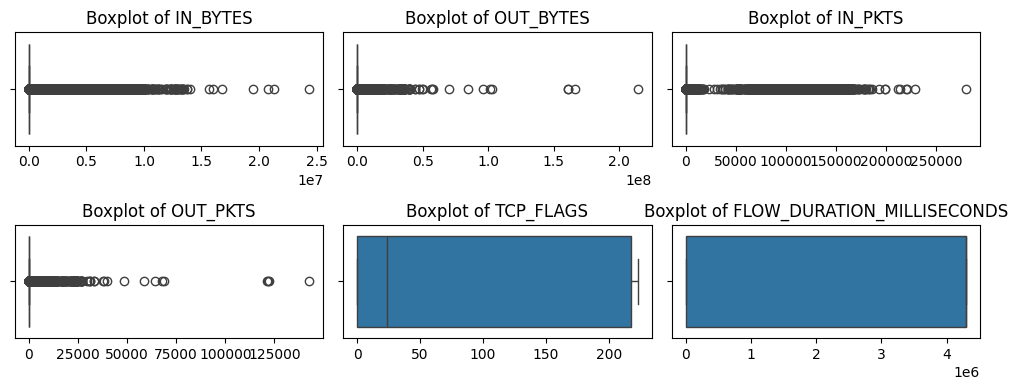

```python
numerical_columns = ['IN_BYTES', 'OUT_BYTES', 'IN_PKTS', 'OUT_PKTS', 'TCP_FLAGS', 'FLOW_DURATION_MILLISECONDS']
plot_boxplots(df, numerical_columns)
```

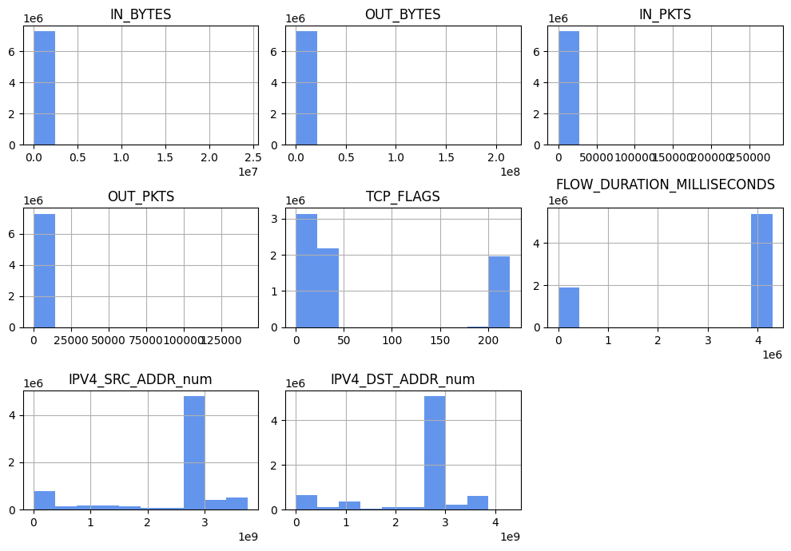

```python
df.hist(color='cornflowerblue', figsize = (10,7))
plt.tight_layout()
plt.show()
```

Remove outliers based on z-scores (remove data points below -3 and above 3.)

- Outliers detected: 10,120 rows

```python
# Select only numerical columns
numerical_columns = ['IN_BYTES', 'OUT_BYTES', 'IN_PKTS', 'OUT_PKTS', 'TCP_FLAGS', 'FLOW_DURATION_MILLISECONDS']

# Initialize a mask for outliers across all numerical columns
outliers_mask = pd.Series(False, index=df.index)

# Iterate through each numerical column
for col in numerical_columns:
    # Calculate mean and standard deviation
    mean = df[col].mean()
    std = df[col].std()

    # Calculate z-scores
    z_scores = (df[col] - mean) / std

    # Identify outliers
    outliers_mask |= (z_scores > 3) | (z_scores < -3)

# Print outliers in the DataFrame
#outliers = df[outliers_mask]
#outliers

print(f"Rows before deletion: {df.shape[0]}")
print(f"Number of outliers: {df[outliers_mask].shape[0]}")
```

```
Rows before deletion: 7296922
Number of outliers: 10120
```

```python
# Remove outliers from the dataframe
df = df[~outliers_mask]
print(f"Rows after deletion: {df.shape[0]}")
```

```
Rows after deletion: 7286802
```

```python
# Check outliers one-by-one (per column)
#mean = df['IN_PKTS'].mean()
#std = df['IN_PKTS'].std()
#df['z_score'] = (df['IN_PKTS'] - mean) / std
#outliers = df[(df['z_score'] > 3) | (df['z_score'] < -3)]
#outliers
```

Check the boxplots and histograms after outliers removal.

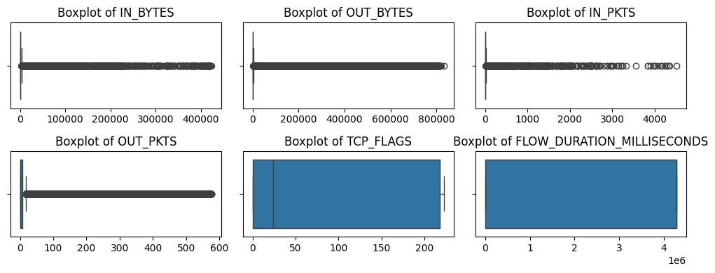

```python
plot_boxplots(df, numerical_columns)
```

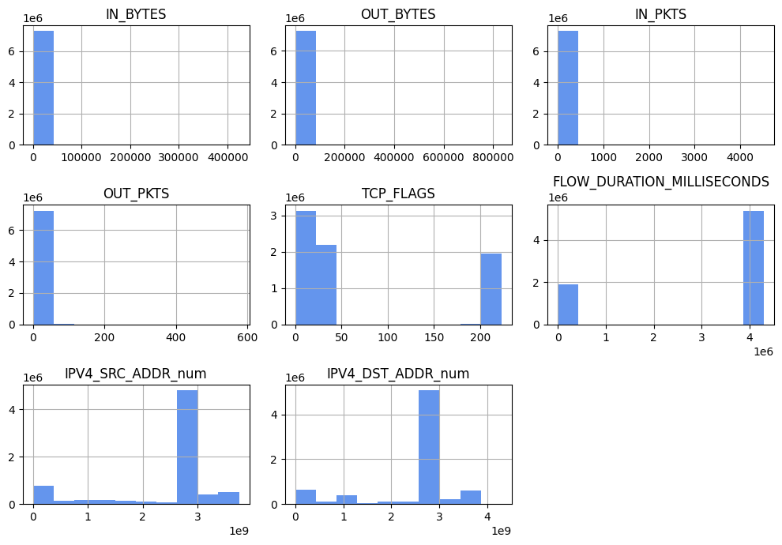

```python
df.hist(color='cornflowerblue', figsize = (10,7))
plt.tight_layout()
plt.show()
```

## **Step 4: Explore Data Characteristics / Distributions**

### **Quantitative Features**: Summary of Findings

- 50% of the FLOW_DURATION_MILLISECONDS for Non-Attacks (Benign) are less than or equal to 4,293,779 ms, indicating that benign traffic tends to have longer sessions. For Attacks, 50% of the flow durations are 0 ms, suggesting that many attack flows are extremely short-lived or even instant. This could indicate scanning activities, quick bursts, or dropped connections during the attack.
- The central tendency for IN_BYTES are higher for Attacks than those Non-Attacks (Benign), indicating that attacks may involve larger amounts of data being sent to the target. This could reflect data-heavy attack types, like Denial of Service (DoS) or data exfiltration attempts. The same is observed for IN_PKTS, indicating that attacks may generate a higher volume of packets, possibly as part of volumetric attacks or network floods.
- 50% of the OUT_BYTES for Non-Attacks (Benign) are less than or equal to 160 bytes, indicating that attacks may generate a higher volume of packets, possibly as part of volumetric attacks or network floods while for Attacks is 0 bytes.
- For Non-Attacks (Benign), 50% of the OUT_BYTES are less than or equal to 160 bytes and 50% of the OUT_PKTS are less than or equal to packets. This implies that benign flows often involve smaller amounts of data being sent back, typical for normal, light-weight communications like simple queries or acknowledgments. For Attacks, both OUT_BYTES and OUT_PKTS are 0 for 50% of the flows, suggesting many attack flows do not elicit a response from the target, possibly because the target system is overwhelmed, or the attack is one-sided (like in DDoS attacks or certain reconnaissance activities).

Overall, **short flow durations** and **high incoming data volumes** are characteristic of an attack traffic, and **minimal outgoing data and packet counts** for attack flows highlight the often one-sided nature of these attacks.

```python
agg_funcs = ['min', 'max', 'mean', 'median', ('quantile (50%)', lambda x: x.quantile(0.5))]

df.pivot_table(
    values=numerical_columns,
    index='Label',
    aggfunc={col: agg_funcs for col in numerical_columns},
    observed=False
).transpose()
```

|  | Label | 0 | 1 |
| --- | --- | --- | --- |
| FLOW_DURATION_MILLISECONDS | max | 4294967.00 | 4294967.00 |
|  | mean | 3424893.14 | 483822.23 |
|  | median | 4293779.00 | 0.00 |
|  | min | 0.00 | 0.00 |
|  | quantile (50%) | 4293779.00 | 0.00 |
| IN_BYTES | max | 423477.00 | 127800.00 |
|  | mean | 1050.77 | 2543.19 |
|  | median | 152.00 | 232.00 |
|  | min | 28.00 | 40.00 |
|  | quantile (50%) | 152.00 | 232.00 |
| IN_PKTS | max | 4516.00 | 2130.00 |
|  | mean | 6.99 | 20.99 |
|  | median | 3.00 | 5.00 |
|  | min | 1.00 | 1.00 |
|  | quantile (50%) | 3.00 | 5.00 |
| OUT_BYTES | max | 833484.00 | 634164.00 |
|  | mean | 2008.66 | 219.10 |
|  | median | 160.00 | 0.00 |
|  | min | 0.00 | 0.00 |
|  | quantile (50%) | 160.00 | 0.00 |
| OUT_PKTS | max | 576.00 | 465.00 |
|  | mean | 4.93 | 0.56 |
|  | median | 2.00 | 0.00 |
|  | min | 0.00 | 0.00 |
|  | quantile (50%) | 2.00 | 0.00 |
| TCP_FLAGS | max | 223.00 | 223.00 |
|  | mean | 66.64 | 99.29 |
|  | median | 24.00 | 27.00 |
|  | min | 0.00 | 0.00 |
|  | quantile (50%) | 24.00 | 27.00 |

```python
def plot_grouped_boxplots(df, group_data_by, numerical_columns):
    # Calculate the number of rows needed based on the number of numerical columns
    num_cols = 2  # Number of columns per row
    num_rows = math.ceil(len(numerical_columns) / num_cols)  # Calculate rows dynamically

    # Create a figure for the box plots
    plt.figure(figsize=(10, 3 * num_rows))  # Adjust figure height based on rows

    # Iterate through numerical columns and create a box plot for each
    for i, column in enumerate(numerical_columns, 1):
        plt.subplot(num_rows, num_cols, i)  # Use calculated rows and columns
        sns.boxplot(x=group_data_by, y=column, data=df)
        plt.title(f'Box Plot of {column} by {group_data_by}')
        plt.xlabel('Label')
        plt.ylabel(column)

    # Adjust layout and display the plots
    plt.tight_layout()
    plt.show()
```

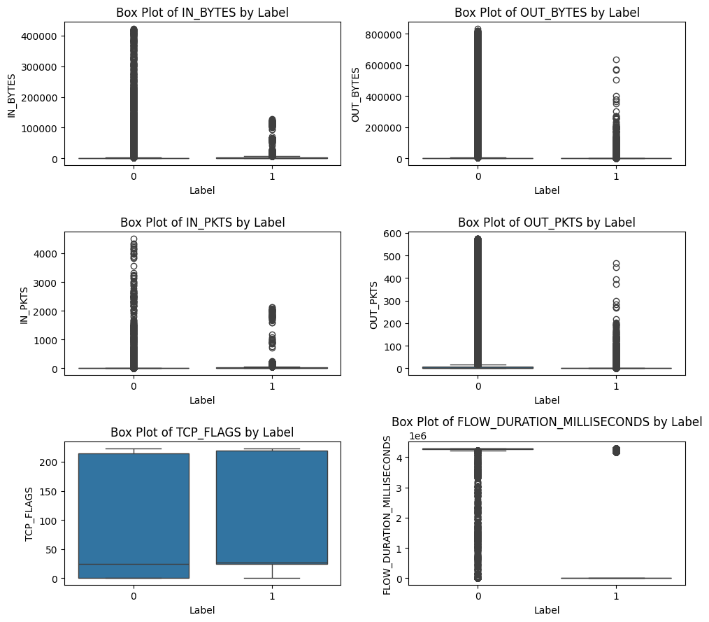

```python
# Show all numerical columns grouped by 'Label'
plot_grouped_boxplots(df, 'Label', numerical_columns)
```

- **Bot**, **Infiltration**, and **Web Attacks** show sustained and lengthy durations, pointing towards complex or persistent attack strategies.
- **BruteForce** and **DoS** attacks consistently display zero durations, suggesting immediate failure or potentially flawed data capture.
- **DDoS** attacks exhibit a mix of high maximum duration and zero median/quantile, reflecting the bursty and often short-lived nature of these attacks.

```python
agg_funcs = ['min', 'max', 'mean', 'median', ('quantile (50%)', lambda x: x.quantile(0.5))]

df.pivot_table(
    values=numerical_columns,
    index='Attack_simplified',
    aggfunc={col: agg_funcs for col in numerical_columns},
    observed=False
).transpose()
```

|  | Attack_simplified | Benign | Bot | BruteForce | DDoS | DoS | Infiltration | Web Attacks |
| --- | --- | --- | --- | --- | --- | --- | --- | --- |
| FLOW_DURATION_MILLISECONDS | max | 4294967.00 | 4294966.00 | 0.00 | 4289966.00 | 0.00 | 4294967.00 | 4294966.00 |
|  | mean | 3424893.14 | 4294953.23 | 0.00 | 3298.00 | 0.00 | 3963813.60 | 3984291.05 |
|  | median | 4293779.00 | 4294955.00 | 0.00 | 0.00 | 0.00 | 4294939.00 | 4244521.50 |
|  | min | 0.00 | 4293937.00 | 0.00 | 0.00 | 0.00 | 0.00 | 0.00 |
|  | quantile (50%) | 4293779.00 | 4294955.00 | 0.00 | 0.00 | 0.00 | 4294939.00 | 4244521.50 |
| IN_BYTES | max | 423477.00 | 2354.00 | 3484.00 | 127800.00 | 24321.00 | 31520.00 | 64582.00 |
|  | mean | 1050.77 | 536.11 | 2653.81 | 223.11 | 7358.75 | 441.99 | 28295.24 |
|  | median | 152.00 | 538.00 | 3132.00 | 192.00 | 4098.00 | 111.00 | 2640.00 |
|  | min | 28.00 | 152.00 | 60.00 | 40.00 | 52.00 | 40.00 | 172.00 |
|  | quantile (50%) | 152.00 | 538.00 | 3132.00 | 192.00 | 4098.00 | 111.00 | 2640.00 |
| IN_PKTS | max | 4516.00 | 6.00 | 29.00 | 2130.00 | 162.00 | 262.00 | 207.00 |
|  | mean | 6.99 | 4.99 | 19.81 | 4.16 | 57.87 | 3.97 | 82.82 |
|  | median | 3.00 | 5.00 | 23.00 | 4.00 | 32.00 | 2.00 | 6.00 |
|  | min | 1.00 | 3.00 | 1.00 | 1.00 | 1.00 | 1.00 | 1.00 |
|  | quantile (50%) | 3.00 | 5.00 | 23.00 | 4.00 | 32.00 | 2.00 | 6.00 |
| OUT_BYTES | max | 833484.00 | 4021.00 | 0.00 | 199753.00 | 0.00 | 634164.00 | 199753.00 |
|  | mean | 2008.66 | 345.85 | 0.00 | 63.50 | 0.00 | 1587.57 | 62138.33 |
|  | median | 160.00 | 341.00 | 0.00 | 0.00 | 0.00 | 155.00 | 2060.50 |
|  | min | 0.00 | 92.00 | 0.00 | 0.00 | 0.00 | 0.00 | 0.00 |
|  | quantile (50%) | 160.00 | 341.00 | 0.00 | 0.00 | 0.00 | 155.00 | 2060.50 |
| OUT_PKTS | max | 576.00 | 97.00 | 0.00 | 110.00 | 0.00 | 465.00 | 110.00 |
|  | mean | 4.93 | 5.12 | 0.00 | 0.05 | 0.00 | 4.11 | 47.51 |
|  | median | 2.00 | 5.00 | 0.00 | 0.00 | 0.00 | 1.00 | 5.00 |
|  | min | 0.00 | 2.00 | 0.00 | 0.00 | 0.00 | 0.00 | 0.00 |
|  | quantile (50%) | 2.00 | 5.00 | 0.00 | 0.00 | 0.00 | 1.00 | 5.00 |
| TCP_FLAGS | max | 223.00 | 219.00 | 27.00 | 222.00 | 31.00 | 223.00 | 219.00 |
|  | mean | 66.64 | 219.00 | 22.85 | 168.32 | 24.63 | 48.32 | 168.15 |
|  | median | 24.00 | 219.00 | 27.00 | 218.00 | 27.00 | 0.00 | 219.00 |
|  | min | 0.00 | 214.00 | 2.00 | 0.00 | 2.00 | 0.00 | 0.00 |
|  | quantile (50%) | 24.00 | 219.00 | 27.00 | 218.00 | 27.00 | 0.00 | 219.00 |

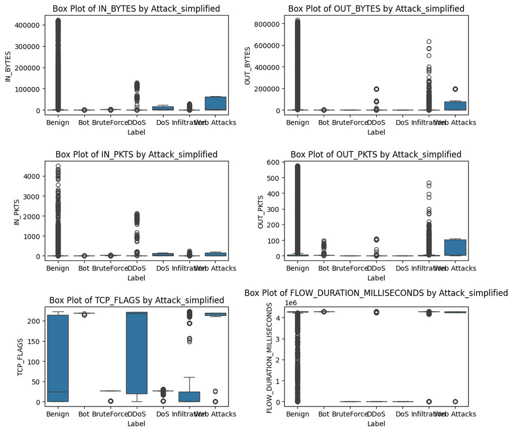

```python
# Show all numerical columns grouped by 'Attack_simplified'
plot_grouped_boxplots(df, 'Attack_simplified', numerical_columns)
```

### **Qualitative Features**: Summary of Findings

- **Source and Destination IPs:** Certain IPs like 172.31.69.25 and 172.31.0.2 are central hubs for traffic, both in non-attack and attack scenarios, with distinct IPs associated with attacks, potentially identifying compromised sources or key targets.
- **Ports:** Non-attack traffic focuses on standard service ports like 3389 (RDP), 53 (DNS), 443 (HTTPS) and 80 (HTTP), while attack traffic shows a mix of high-frequency ports like 58692, 58834, 58179, 33918, 58829 and a strong focus on HTTP (Port 80), aligning with typical attack patterns.
- **Protocols and Flags:** Attack traffic leverages TCP extensively, often using non-standard TCP flags such as 27 and 222 (non-standard or less common flag combinations) and masked Layer 7 protocols (0 for unidentified), reflecting common strategies for evasion and attack.

Overall, these patterns IP addresses, ports, and protocol behaviors can aid in the identification and mitigation of an attack traffic.

```python
def plot_filtered_bar_charts(df, label_filter, columns_to_plot, color='skyblue', figure_title=''):
    # Calculate the number of rows needed based on the number of columns to plot
    num_columns = 2  # Number of columns per row
    num_rows = math.ceil(len(columns_to_plot) / num_columns)  # Calculate rows dynamically

    plt.figure(figsize=(12, num_rows * 4))  # Adjust figure size as needed

    # Iterate through columns and create bar charts for each
    for i, column in enumerate(columns_to_plot, 1):
        plt.subplot(num_rows, num_columns, i)

        # Filter the DataFrame for the given label_filter list
        filtered_data_for_column = df[df['Label'].isin(label_filter)][column]

        # Calculate value counts for the column and select the top 10 highest frequencies
        value_counts = filtered_data_for_column.value_counts().nlargest(10)

        # Plot bar chart
        ax = value_counts.plot(kind='bar', color=color)

        # Add percentage labels to the bars
        total_count = value_counts.sum()
        for p in ax.patches:
            height = p.get_height()
            ax.annotate(f'{height / total_count * 100:.1f}%',
                        (p.get_x() + p.get_width() / 2., height),
                        ha='center', va='center', fontsize=10, color='black',
                        xytext=(0, 5), textcoords='offset points')

        # Set the title and clean up
        plt.title(f'Frequency of {column}')
        plt.ylabel('Frequency')
        plt.xlabel(column)

    # Add a title for the entire figure (subplot grid)
    if figure_title:
        plt.suptitle(figure_title, fontsize=16)

    # Adjust layout to make sure bar charts fit
    plt.tight_layout()

    # Display the plots
    plt.show()
```

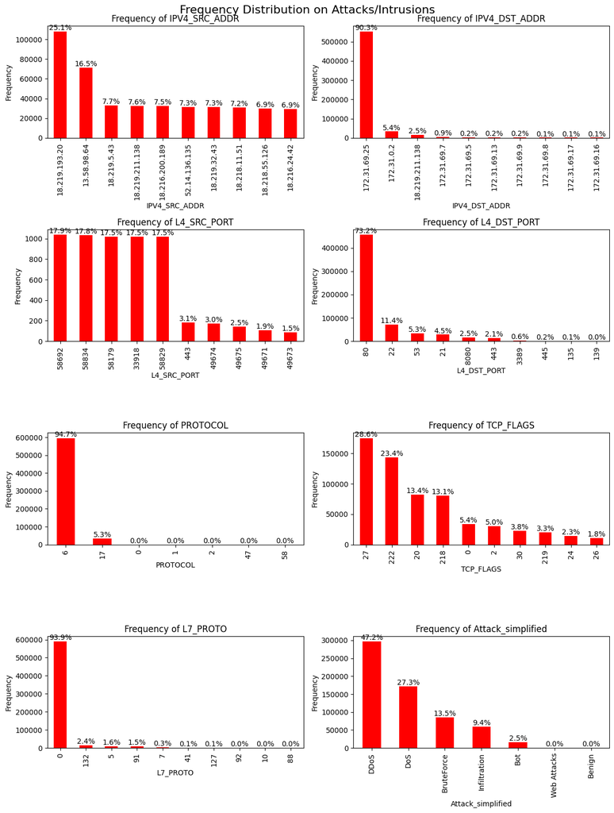

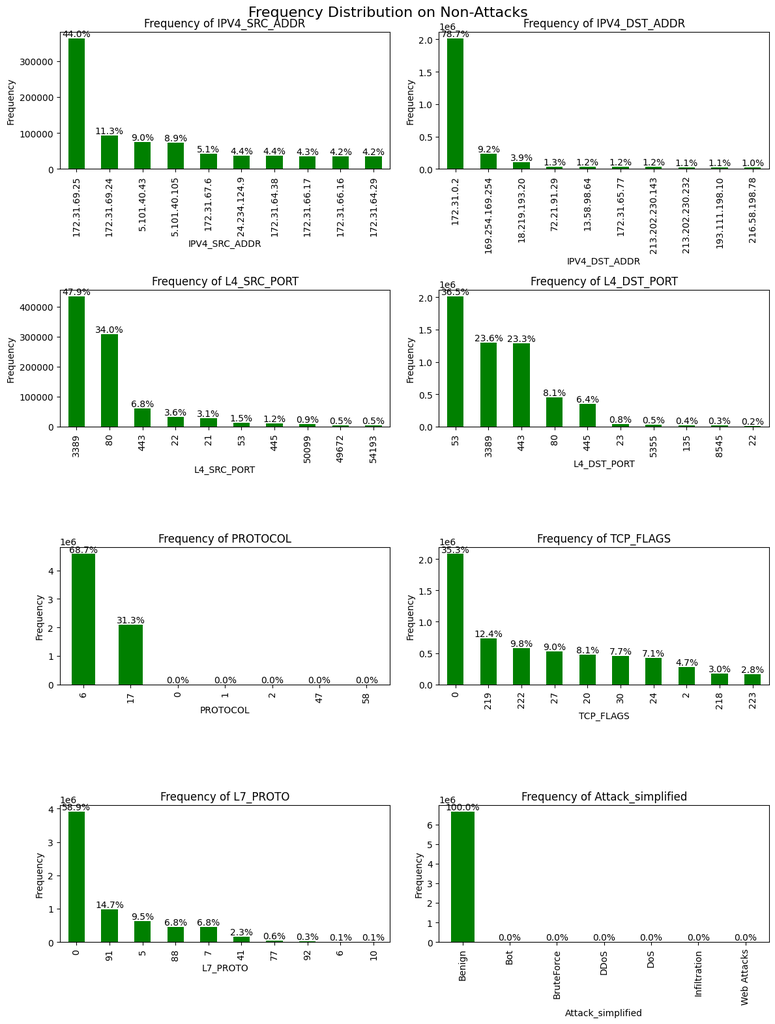

```python
plot_columns_1 = ['IPV4_SRC_ADDR', 'IPV4_DST_ADDR', 'L4_SRC_PORT', 'L4_DST_PORT', 'PROTOCOL', 'TCP_FLAGS', 'L7_PROTO', 'Label', 'Attack_simplified']
plot_columns_2 = ['IPV4_SRC_ADDR', 'IPV4_DST_ADDR', 'L4_SRC_PORT', 'L4_DST_PORT', 'PROTOCOL', 'TCP_FLAGS', 'L7_PROTO', 'Attack_simplified']

# Show all Labels: Intrusion & Non-Intrusion
#plot_filtered_bar_charts(df, [0, 1], plot_columns_1,
#                         figure_title='Frequency Distribution on All Labels')

# Show only the Label: Intrusion
plot_filtered_bar_charts(df, [1], plot_columns_2, color='red',
                         figure_title='Frequency Distribution on Attacks/Intrusions')

 # Show only the Label: Non-Intrusion
plot_filtered_bar_charts(df, [0], plot_columns_2, color='green',
                         figure_title='Frequency Distribution on Non-Attacks')
```

- In terms of the distribution of the attacks, Distributed Denial of Service (DDoS) is the highest occuring with 47%, followed by Denial of Service (DoS) at 27%, then BruteForce (13%), Infiltration (9%), Bot (2%), Web Attacks (0.1%).

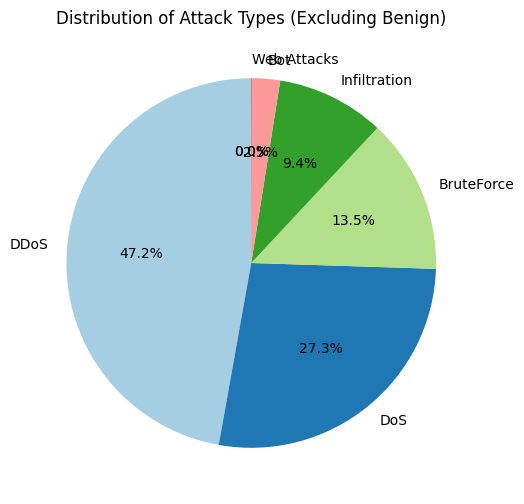

```python
# Filter out 'Benign' from the 'Attack_simplified' column
filtered_data = df[df['Attack_simplified'] != 'Benign']['Attack_simplified']

# Count the occurrences of each unique category
attack_counts = filtered_data.value_counts()

# Plot the pie chart
plt.figure(figsize=(6, 6))
attack_counts.plot(kind='pie', autopct='%1.1f%%', startangle=90, colors=plt.cm.Paired.colors)
plt.title('Distribution of Attack Types (Excluding Benign)')
plt.ylabel('')  # To hide the y-label
plt.show()
```

**Feature correlation:** OUT_PKTS & OUT_BYTES (0.92) and IN_PKTS & IN_BYTES (0.73) show a strong positive linear relationship. As the number of incoming/outgoing packets increases, the number of incoming/outgoing bytes tends to increase as well.

- In machine learning models, highly correlated features can lead to issues such as multicollinearity and overfitting. For tree-based models (e.g., Random Forest, XGBoost): These models are generally more robust to multicollinearity and can handle correlated features better.

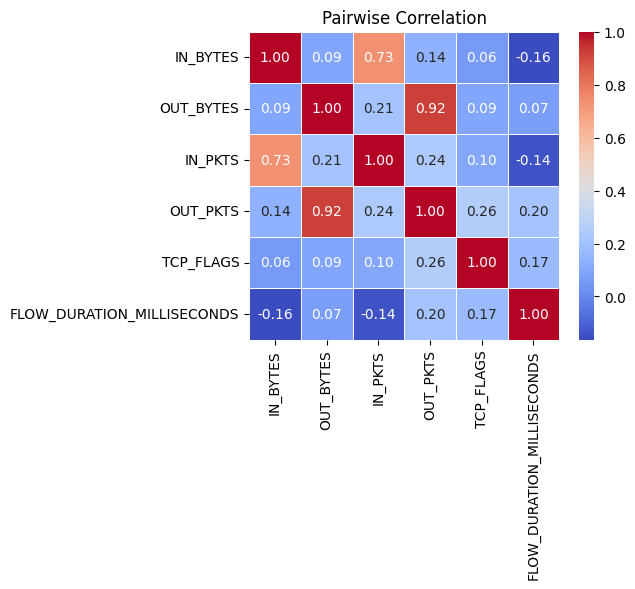

```python
# Plot feature correlation (heatmap)
correlation_matrix = df[numerical_columns].corr()

# Plotting the correlation matrix
plt.figure(figsize=(5, 4))
sns.heatmap(correlation_matrix, annot=True, cmap='coolwarm', fmt='.2f', linewidths=0.5)
plt.title('Pairwise Correlation')
plt.show()
```

- Check Multicollinearity (VIF)

```python
from statsmodels.stats.outliers_influence import variance_inflation_factor
from statsmodels.tools.tools import add_constant

# add a constant term to the data to fit the intercept of the model
df_with_const = add_constant(df[numerical_columns])

# calculate VIF for each feature
vif = pd.DataFrame()
vif["feature"] = df_with_const.columns
vif["VIF"] = [variance_inflation_factor(df_with_const.values, i) for i in range(df_with_const.shape[1])]
vif
```

|  | feature | VIF |
| --- | --- | --- |
| 0 | const | 4.30 |
| 1 | IN_BYTES | 2.14 |
| 2 | OUT_BYTES | 7.69 |
| 3 | IN_PKTS | 2.18 |
| 4 | OUT_PKTS | 8.90 |
| 5 | TCP_FLAGS | 1.24 |
| 6 | FLOW_DURATION_MILLISECONDS | 1.22 |

## **Step 5: Feature Engineering**

### **Encoding categorical variables**

1. We'll be using **Label Encoding** which assigns an integer value to each category for the variable below. This can unintentionally introduce a sense of order or hierarchy to the data, even though there is no actual order. However, ML models like Decision Trees, Random Forests, and Gradient Boosting algorithms are not sensitive to the numerical order of the categories.

```python
df.describe(include=['category'])
```

|  | IPV4_SRC_ADDR | L4_SRC_PORT | IPV4_DST_ADDR | L4_DST_PORT | PROTOCOL | L7_PROTO | Label | Attack | Attack_simplified |
| --- | --- | --- | --- | --- | --- | --- | --- | --- | --- |
| count | 7286802 | 7286802 | 7286802 | 7286802 | 7286802 | 7286802 | 7286802 | 7286802 | 7286802 |
| unique | 74511 | 65009 | 25183 | 65091 | 2 | 86 | 2 | 15 | 7 |
| top | 172.31.69.25 | 3389 | 172.31.0.2 | 53 | 6 | 0 | 0 | Benign | Benign |
| freq | 361894 | 433849 | 2043259 | 2045001 | 5169991 | 4499020 | 6657213 | 6657213 | 6657213 |

```python
from sklearn.preprocessing import LabelEncoder

label_encoder = LabelEncoder()
columns_to_encode = ['Attack_simplified', 'Attack', 'L7_PROTO', 'PROTOCOL']

for column in columns_to_encode:
    new_column = column + '_encoded'  # Create new column name
    df[new_column] = label_encoder.fit_transform(df[column])  # Encode and store in new column
```

```python
# # For checking
# df[['Attack', 'Attack_encoded']].value_counts()
# df[['Attack_simplified', 'Attack_simplified_encoded']].value_counts()
# df[['L7_PROTO', 'L7_PROTO_encoded']].value_counts()
# df[['PROTOCOL', 'PROTOCOL_encoded']].value_counts()
```

2. Since the following variables have a very large number of categories (high cardinality), we will be using Hashing Encoding to reduce the dimensionality of high-cardinality categorical features by mapping them into a fixed number of buckets (n_buckets).
   - IPV4_SRC_ADDR
   - L4_SRC_PORT
   - IPV4_DST_ADDR
   - L4_DST_PORT

   In **Hashing Encoding**, each unique value in the categorical column is passed through a hash function, which then maps it to one of n_buckets buckets. This means multiple distinct values might end up in the same bucket (hash collisions).

   There are other more complex techniques to handle high cardinality cases such as Categorical Embeddings, which needs to be explored in the future.

```python
# List of categorical features to encode
categorical_features = ['IPV4_SRC_ADDR', 'IPV4_DST_ADDR', 'L4_SRC_PORT', 'L4_DST_PORT']

# Define the number of hash buckets
n_buckets = 10

# Manual Hashing Encoding for IPV4_SRC_ADDR
for col in categorical_features:
    df[col + '_encoded'] = df[col].apply(lambda x: hash(x) % n_buckets)

# Show the DataFrame with the encoded columns
df.head()
```

|  | IPV4_SRC_ADDR | L4_SRC_PORT | IPV4_DST_ADDR | L4_DST_PORT | PROTOCOL | L7_PROTO | IN_BYTES | OUT_BYTES | IN_PKTS | OUT_PKTS | ... | IPV4_SRC_ADDR_num | IPV4_DST_ADDR_num | Attack_simplified_encoded | Attack_encoded | L7_PROTO_encoded | PROTOCOL_encoded | IPV4_SRC_ADDR_encoded | IPV4_DST_ADDR_encoded | L4_SRC_PORT_encoded | L4_DST_PORT_encoded |
| --- | --- | --- | --- | --- | --- | --- | --- | --- | --- | --- | --- | --- | --- | --- | --- | --- | --- | --- | --- | --- | --- |
| 0 | 172.31.66.17 | 51128 | 23.36.69.189 | 443 | 6 | 91 | 152 | 0 | 3 | 0 | ... | 2887729681 | 388253117 | 0 | 0 | 37 | 0 | 7 | 3 | 8 | 3 |
| 1 | 34.195.59.178 | 443 | 172.31.66.17 | 51036 | 6 | 91 | 994 | 979 | 7 | 7 | ... | 583220146 | 2887729681 | 0 | 0 | 37 | 0 | 6 | 7 | 3 | 6 |
| 2 | 112.215.171.212 | 12262 | 172.31.66.17 | 445 | 6 | 0 | 585 | 344 | 5 | 4 | ... | 1893182420 | 2887729681 | 0 | 0 | 0 | 0 | 4 | 7 | 2 | 5 |
| 3 | 172.31.66.17 | 61023 | 172.31.0.2 | 53 | 17 | 0 | 136 | 168 | 2 | 2 | ... | 2887729681 | 2887712770 | 0 | 0 | 0 | 1 | 7 | 9 | 3 | 3 |
| 4 | 34.204.112.168 | 443 | 172.31.66.17 | 51037 | 6 | 91 | 72 | 40 | 1 | 1 | ... | 583823528 | 2887729681 | 0 | 0 | 37 | 0 | 2 | 7 | 3 | 7 |

5 rows × 25 columns

### **Transforming & Scaling Numerical (Continuous) Variables**

When dealing with highly skewed continuous variables (characterized by a long tail and a few large values), transformations like log(x+1) can help normalize the distribution. This normalization can enhance model performance and interpretability.

- **Log Transformation and Other Techniques:**
  - These transformations can make skewed distributions more symmetric, improving the performance of models that assume normally distributed features or those that benefit from reduced skewness.
- **Scaling for Different Types of Models:**
  - Linear Models (e.g., Logistic Regression, Linear Regression):
    - Scaling is important as these models are sensitive to the magnitude of feature values. Large differences in scale can lead to instability in the coefficients and affect model performance.
  - Distance-Based Models (e.g., K-Nearest Neighbors, Support Vector Machines with RBF kernel):
    - These models rely on distance calculations between data points. If features are on different scales, it can distort the distance computations, leading to poor model performance. Hence, scaling ensures each feature contributes equally to the distance metric.
  - Tree-Based Models (e.g., Random Forest, XGBoost):
    - These models are robust to skewed distributions and differences in feature scales. They split data based on feature thresholds rather than relying on distance or gradients. Therefore, transformations and scaling are generally not necessary for tree-based models, as they inherently handle feature variations well.

Below transformations may or may not be needed (keeping it here for reference).

```python
# # Plot original distribution
# plt.hist(df['IN_BYTES'], bins=50)
# plt.title('Original Distribution of IN_BYTES')
# plt.show()

# # Check skewness
# print("Skewness:", df['IN_BYTES'].skew())
```

```python
# # Apply log transformation
# import numpy as np

# df['IN_BYTES_log'] = np.log1p(df['IN_BYTES'])  # log(x + 1)

# # Plot transformed distribution
# plt.hist(df['IN_BYTES_log'], bins=50)
# plt.title('Log-Transformed Distribution')
# plt.show()

# # Check skewness after transformation
# print("Skewness after log transformation:", df['IN_BYTES_log'].skew())
```

```python
# # After log transformation, apply min-max scaling to bring the values into the [0, 1] range,
# # which is often beneficial for models like Random Forest.

# from sklearn.preprocessing import MinMaxScaler

# scaler = MinMaxScaler()
# df['IN_BYTES_scaled'] = scaler.fit_transform(df[['IN_BYTES_log']])

# print(df[['IN_BYTES', 'IN_BYTES_log', 'IN_BYTES_scaled']])
```

```python
# Eliminate variables with constant zero values or very low variance
```

## **Step 6: Feature Selection (Univariate Methods)**

- **Method:** Retain features that are most important to the model and discard those that contribute little to the performance, using 60% threshold for each of the univariate tests, since we only have a few.
- **Note:** IPV4_SRC_ADDR, IPV4_DST_ADDR, L4_SRC_PORT, L4_DST_PORT have been excluded before proceeding with Feature Selection since these variables are infrastructure-dependent and may be considered redundant. As a result, many research papers exclude these features from their machine learning models, and also due to their nature as high-cardinality categorical variables.

```python
# Set the precision in pandas for display
pd.options.display.float_format = '{:.8f}'.format
```

### 1) Chi-square test

- Evaluates whether there is a significant association between each feature (independent variable) and the target (dependent variable). Works with categorical features and a categorical target.
- Results show that all categorical features in our dataset are important, starting with TCP_FLAGS, followed by L7_PROTO and PROTOCOL.
- Applying 60% threshold, I'll be selecting the top 2: **TCP_FLAGS, L7_PROTO**.

```python
from sklearn.feature_selection import SelectKBest, chi2

# Categorical features
categorical_features = df[['TCP_FLAGS', 'L7_PROTO_encoded', 'PROTOCOL_encoded']]
target = df['Label']  # 0 (non-attack) or 1 (attack)

# Apply Chi-Square
chi_scores, p_values = chi2(categorical_features, target)
chi_square_results = pd.DataFrame({
    'Feature': categorical_features.columns,
    'Chi-Square': chi_scores,
    'p-value': p_values
})
chi_square_results
```

|  | Feature | Chi-Square | p-value |
| --- | --- | --- | --- |
| 0 | TCP_FLAGS | 8826785.13525725 | 0.00000000 |
| 1 | L7_PROTO_encoded | 3765967.29150764 | 0.00000000 |
| 2 | PROTOCOL_encoded | 133727.60957196 | 0.00000000 |

### 2) ANOVA (F-Test)

- Tests whether the mean of a numerical feature differs significantly between the classes of a categorical target.
- Results show that FLOW_DURATION_MILLISECONDS has the most significant effect to the attack type, followed by IN_PKTS, IN_BYTES, OUT_PKTS and OUT_BYTES.
- Applying 60% threshold, I'll be selecting the top 3: **FLOW_DURATION_MILLISECONDS, IN_PKTS, IN_BYTES**.

```python
from sklearn.feature_selection import f_classif

# Numerical features
numerical_features = df[['IN_BYTES', 'OUT_BYTES', 'IN_PKTS', 'OUT_PKTS', 'FLOW_DURATION_MILLISECONDS']]
target = df['Label']

# Apply ANOVA
f_scores, p_values = f_classif(numerical_features, target)
anova_results = pd.DataFrame({
    'Feature': numerical_features.columns,
    'F-Score': f_scores,
    'p-value': p_values
})
anova_results
```

|  | Feature | F-Score | p-value |
| --- | --- | --- | --- |
| 0 | IN_BYTES | 80085.18733542 | 0.00000000 |
| 1 | OUT_BYTES | 8408.55719867 | 0.00000000 |
| 2 | IN_PKTS | 221435.64976087 | 0.00000000 |
| 3 | OUT_PKTS | 71509.37209906 | 0.00000000 |
| 4 | FLOW_DURATION_MILLISECONDS | 1740588.93011464 | 0.00000000 |

### 3) Mutual Information

- Measures how much information about the target is provided by each feature. Works with both numerical and categorical data.
- Results show that IN_BYTES provides the most information, followed by FLOW_DURATION_MILLISECONDS, TCP_FLAGS, OUT_PKTS, OUT_BYTES, L7_PROTO, IN_PKTS and PROTOCOL.
- Applying 60% threshold, I'll be selecting the top 5: **IN_BYTES, FLOW_DURATION_MILLISECONDS, TCP_FLAGS, OUT_PKTS, OUT_BYTES**.

```python
from sklearn.feature_selection import mutual_info_classif

# All features
features = df[['IN_BYTES', 'OUT_BYTES', 'IN_PKTS', 'OUT_PKTS', 'FLOW_DURATION_MILLISECONDS',
               'TCP_FLAGS', 'L7_PROTO_encoded', 'PROTOCOL_encoded']]
target = df['Label']

# Apply Mutual Information
mi_scores = mutual_info_classif(features, target)
mi_results = pd.DataFrame({
    'Feature': features.columns,
    'Mutual Information': mi_scores
}).sort_values(by='Mutual Information', ascending=False)
mi_results
```

|  | Feature | Mutual Information |
| --- | --- | --- |
| 0 | IN_BYTES | 0.17712412 |
| 4 | FLOW_DURATION_MILLISECONDS | 0.13404470 |
| 5 | TCP_FLAGS | 0.12181567 |
| 3 | OUT_PKTS | 0.11957460 |
| 1 | OUT_BYTES | 0.09906132 |
| 6 | L7_PROTO_encoded | 0.09522588 |
| 2 | IN_PKTS | 0.09413762 |
| 7 | PROTOCOL_encoded | 0.00000000 |

### 4) ReliefF

- Evaluates how well a feature distinguishes between neighboring instances of the same class versus neighboring instances of different classes. Works well with numerical and categorical features.
- Results show that L7_PROTO has the greatest discriminatory power, followed by OUT_PKTS, IN_BYTES, IN_PKTS, FLOW_DURATION_MILLISECONDS, OUT_BYTES, TCP_FLAGS and PROTOCOL.
- Applying 60% threshold, I'll be selecting the top 5: **L7_PROTO, OUT_PKTS, IN_BYTES, IN_PKTS, FLOW_DURATION_MILLISECONDS**.

```python
from sklearn.preprocessing import MinMaxScaler
from skrebate import ReliefF
import pandas as pd

# Sample 100,000 rows randomly (to remediate MemoryError)
sampled_df = df.sample(n=10000, random_state=42)

# Features and target
features = sampled_df[['IN_BYTES', 'OUT_BYTES', 'IN_PKTS', 'OUT_PKTS', 'FLOW_DURATION_MILLISECONDS',
               'TCP_FLAGS', 'L7_PROTO_encoded', 'PROTOCOL_encoded']]
target = sampled_df['Label']

# Identify numerical columns for scaling
numerical_columns = ['IN_BYTES', 'OUT_BYTES', 'IN_PKTS', 'OUT_PKTS', 'FLOW_DURATION_MILLISECONDS']

# Scale numerical columns
scaler = MinMaxScaler()
features[numerical_columns] = scaler.fit_transform(features[numerical_columns])

# Apply ReliefF
relief = ReliefF(n_neighbors=10)
relief.fit(features.values, target.values)
relief_scores = relief.feature_importances_

# Create a DataFrame to display the results
relief_results = pd.DataFrame({
    'Feature': features.columns,
    'ReliefF Score': relief_scores
}).sort_values(by='ReliefF Score', ascending=False)
relief_results
```

|  | Feature | ReliefF Score |
| --- | --- | --- |
| 6 | L7_PROTO_encoded | 0.15296951 |
| 3 | OUT_PKTS | 0.06415783 |
| 0 | IN_BYTES | 0.03426117 |
| 2 | IN_PKTS | 0.02630900 |
| 4 | FLOW_DURATION_MILLISECONDS | 0.01372762 |
| 1 | OUT_BYTES | 0.00860681 |
| 5 | TCP_FLAGS | 0.00750704 |
| 7 | PROTOCOL_encoded | 0.00000000 |

### 5) Pearson Correlation

- Measures the linear relationship between a numerical feature and a numerical target.
- Results show that FLOW_DURATION_MILLISECONDS show a moderate linear relationship with the Attack type, followed by IN_PKTS, IN_BYTES, OUT_PKTS and OUT_BYTES.
- Applying 60% threshold, I'll be selecting the top 3: **FLOW_DURATION_MILLISECONDS, IN_PKTS, IN_BYTES**.

```python
# Numerical features
numerical_features = df[['IN_BYTES', 'OUT_BYTES', 'IN_PKTS', 'OUT_PKTS', 'FLOW_DURATION_MILLISECONDS']]
target = df['Label']

# Compute Pearson Correlation
correlation_results = numerical_features.corrwith(target)
print(correlation_results)
```

```
IN_BYTES                      0.10426394
OUT_BYTES                    -0.03395016
IN_PKTS                       0.17173342
OUT_PKTS                     -0.09858083
FLOW_DURATION_MILLISECONDS   -0.43910363
dtype: float64
```

### Combine features based on 60% threshold:

- Given that we have 5 different univariate tests (Chi-square, ANOVA, Mutual Information, ReliefF, and Pearson Correlation) each with varying feature selection criteria, I'll be combining the results of all these tests and retain the top 5 (60%) among the 8 total independent variables in our data set.
  1. FLOW_DURATION_MILLISECONDS
  2. IN_BYTES
  3. IN_PKTS
  4. TCP_FLAGS
  5. L7_PROTO

```python
from collections import Counter

# Store the features selected from each test after applying the 60% threshold
selected_features_chi2 = ['TCP_FLAGS', 'L7_PROTO']
selected_features_anova = ['FLOW_DURATION_MILLISECONDS', 'IN_PKTS', 'IN_BYTES']
selected_features_mutual_info = ['IN_BYTES', 'FLOW_DURATION_MILLISECONDS', 'TCP_FLAGS', 'OUT_PKTS', 'OUT_BYTES']
selected_features_relief = ['L7_PROTO', 'OUT_PKTS', 'IN_BYTES', 'IN_PKTS', 'FLOW_DURATION_MILLISECONDS']
selected_features_pearson = ['FLOW_DURATION_MILLISECONDS', 'IN_PKTS', 'IN_BYTES']

# Combine all selected features into one list
all_selected_features = selected_features_chi2 + selected_features_anova + \
                         selected_features_mutual_info + selected_features_relief + \
                         selected_features_pearson

# Count the frequency of each feature
feature_counts = Counter(all_selected_features)
feature_counts
```

```
Counter({'FLOW_DURATION_MILLISECONDS': 4,
         'IN_BYTES': 4,
         'IN_PKTS': 3,
         'TCP_FLAGS': 2,
         'L7_PROTO': 2,
         'OUT_PKTS': 2,
         'OUT_BYTES': 1})
```

## **Step 7: Model Building**

My **approach** involves testing multiple combinations of datasets, imbalance handling techniques, and ML models:

- Datasets:
  1. Baseline with all 8 features (excluded IP address & ports which are infrastructure-dependent)
  2. Reduced set with 5 important features (based on univariate results: retained top 60% of most important features)
- Imbalance Handling Techniques:
  1. SMOTE
  2. Random undersampling
  3. Class weight = balanced
- ML Models:
  1. Random Forest
  2. XGBoost
  - Note: I tried to run the test with the following but encountered issues:
    - Logistic Regression: ConvergenceWarning: lbfgs failed to converge (status=1): STOP: TOTAL NO. of ITERATIONS REACHED LIMIT.
    - SVM: Took more than 12 hours to run & did not complete.
- Combinations:
  - 2 (Datasets) x 3 (Imbalance Handling) x 2 (Models) = 12

**Implementation Plan:**

1. **Data Preparation**: Split the data into 80% training and 20% testing, with stratify=y to maintain class balance in the split.
2. **Imbalance Handling**
   - Apply SMOTE (oversampling minority class).
   - Apply random undersampling (reduce majority class).
   - Use class_weight='balanced' directly in applicable ML models (e.g., Logistic Regression, SVM, RF).
3. **Model Training and Testing**
   - Train each of the models on the processed data for each imbalance handling technique and dataset.
   - Evaluate using metrics (accuracy, precision, recall, F1-score, AUC-ROC, AUPRC).
4. **Evaluation**: Display all evaluation metrics for each combination in a summary table and visualize.

```python
# Split the data into X (features) and y (labels): without infrastructure-dependent features
X = df.drop(['Label', 'Attack', 'Attack_simplified', 'Attack_encoded', 'Attack_simplified_encoded', # Remove target variables (Label - binary; Attack - multiclass)
             'IPV4_SRC_ADDR_num', 'IPV4_DST_ADDR_num', # Remove unused variables
             'L7_PROTO', 'PROTOCOL', # Remove the original encoded variables
             'IPV4_SRC_ADDR_encoded', 'IPV4_DST_ADDR_encoded', 'L4_SRC_PORT_encoded', 'L4_DST_PORT_encoded', # Remove high infra dependent X
             'IPV4_SRC_ADDR', 'L4_SRC_PORT', 'IPV4_DST_ADDR', 'L4_DST_PORT'], # Remove high cardinality variables
            axis=1)  # Features
y = df['Label']  # Target variable (binary classification)

print(X.columns.tolist())
```

```
['IN_BYTES', 'OUT_BYTES', 'IN_PKTS', 'OUT_PKTS', 'TCP_FLAGS', 'FLOW_DURATION_MILLISECONDS', 'L7_PROTO_encoded', 'PROTOCOL_encoded']
```

```python
from sklearn.model_selection import train_test_split
from imblearn.over_sampling import SMOTE
from imblearn.under_sampling import RandomUnderSampler
from sklearn.ensemble import RandomForestClassifier
from xgboost import XGBClassifier
from sklearn.svm import SVC
from sklearn.linear_model import LogisticRegression
from sklearn.metrics import accuracy_score, precision_score, recall_score, f1_score, roc_auc_score
from sklearn.metrics import average_precision_score

def preprocess_data(X, y, imbalance_method=None):
    # Train-test split with stratification
    X_train, X_test, y_train, y_test = train_test_split(X, y, test_size=0.2, stratify=y, random_state=42)

    # Apply imbalance handling method
    if imbalance_method == 'smote':
        smote = SMOTE(random_state=42)
        X_train, y_train = smote.fit_resample(X_train, y_train)
    elif imbalance_method == 'undersampling':
        undersampler = RandomUnderSampler(random_state=42)
        X_train, y_train = undersampler.fit_resample(X_train, y_train)

    return X_train, X_test, y_train, y_test

def train_and_evaluate(X_train, X_test, y_train, y_test, model_type, class_weight=None):
    # Initialize model
    if model_type == 'rf':
        model = RandomForestClassifier(class_weight=class_weight, random_state=42)
    elif model_type == 'xgboost':
        model = XGBClassifier(scale_pos_weight=(len(y_train) - sum(y_train)) / sum(y_train), random_state=42)
    elif model_type == 'svm':
        model = SVC(probability=True, class_weight=class_weight, random_state=42)
    elif model_type == 'logreg':
        model = LogisticRegression(class_weight=class_weight, random_state=42)

    # Train model
    model.fit(X_train, y_train)

    # Predict
    y_pred = model.predict(X_test)
    y_prob = model.predict_proba(X_test)[:, 1] if hasattr(model, 'predict_proba') else None

    # Evaluate
    results = {
        'accuracy': accuracy_score(y_test, y_pred),
        'precision': precision_score(y_test, y_pred),
        'recall': recall_score(y_test, y_pred),
        'f1-score': f1_score(y_test, y_pred),
        'roc_auc': roc_auc_score(y_test, y_prob) if y_prob is not None else None,
        'auprc': average_precision_score(y_test, y_prob) if y_prob is not None else None,
    }

    return results

def run_experiments(X, y):
    datasets = {'baseline': X, 'reduced': X.iloc[:, [0,2,4,5,6]]}  # Select 5 columns from our Feature Selection
    imbalance_methods = ['smote', 'undersampling', None]  # None for class_weight='balanced'
    models = ['xgboost', 'rf'] #['rf', 'xgboost' - 16 min, 'svm', 'logreg' - error]

    results = []

    for dataset_name, dataset in datasets.items():
        for imbalance_method in imbalance_methods:
            for model_type in models:
                X_train, X_test, y_train, y_test = preprocess_data(dataset, y, imbalance_method)
                class_weight = 'balanced' if imbalance_method is None else None
                metrics = train_and_evaluate(X_train, X_test, y_train, y_test, model_type, class_weight)
                metrics.update({
                    'dataset': dataset_name,
                    'imbalance_method': imbalance_method or 'class_weight',
                    'model': model_type
                })
                results.append(metrics)

    return pd.DataFrame(results)

# def plot_results(results_df, metric):
#     plt.figure(figsize=(6, 4))
#     sns.barplot(
#         data=results_df,
#         x='model',
#         y=metric,
#         hue='dataset',
#         dodge=True
#     )
#     plt.title(f'{metric.upper()} Comparison Across Models and Datasets')
#     plt.ylabel(metric.capitalize())
#     plt.xlabel('Model')
#     plt.legend(title='Dataset')
#     plt.show()
```

```python
results = run_experiments(X, y)
results
```

|  | accuracy | precision | recall | f1-score | roc_auc | auprc | dataset | imbalance_method | model |
| --- | --- | --- | --- | --- | --- | --- | --- | --- | --- |
| 0 | 0.98481296 | 0.90597789 | 0.91966994 | 0.91277257 | 0.98095877 | 0.94173129 | baseline | smote | xgboost |
| 1 | 0.98060673 | 0.86314584 | 0.92167919 | 0.89145271 | 0.97463941 | 0.93660236 | baseline | smote | rf |
| 2 | 0.98485825 | 0.90650321 | 0.91959847 | 0.91300388 | 0.98114541 | 0.94176222 | baseline | undersampling | xgboost |
| 3 | 0.97221416 | 0.78953755 | 0.92497498 | 0.85190684 | 0.97878020 | 0.93877997 | baseline | undersampling | rf |
| 4 | 0.98524525 | 0.91079480 | 0.91926492 | 0.91501026 | 0.98112453 | 0.94191012 | baseline | class_weight | xgboost |
| 5 | 0.98355727 | 0.89309922 | 0.91978907 | 0.90624768 | 0.97199308 | 0.93730693 | baseline | class_weight | rf |
| 6 | 0.98545933 | 0.91458635 | 0.91738274 | 0.91598241 | 0.98025056 | 0.94033310 | reduced | smote | xgboost |
| 7 | 0.98269749 | 0.88459952 | 0.91972554 | 0.90182062 | 0.97602295 | 0.93792575 | reduced | smote | rf |
| 8 | 0.98511968 | 0.91032990 | 0.91822456 | 0.91426018 | 0.98056366 | 0.94058644 | reduced | undersampling | xgboost |
| 9 | 0.97647872 | 0.82591099 | 0.92213981 | 0.87137674 | 0.97804080 | 0.93794088 | reduced | undersampling | rf |
| 10 | 0.98539415 | 0.91308193 | 0.91837545 | 0.91572104 | 0.98066160 | 0.94104445 | reduced | class_weight | xgboost |
| 11 | 0.98467778 | 0.90556582 | 0.91843898 | 0.91195698 | 0.97438767 | 0.93820423 | reduced | class_weight | rf |

```python
## Display grouped results
#results.groupby(['dataset', 'model', 'imbalance_method']).mean()
```

```python
# Convert metric columns to numeric
metric_columns = ['accuracy', 'precision', 'recall', 'f1-score', 'roc_auc', 'auprc']
for col in metric_columns:
    results[col] = pd.to_numeric(results[col], errors='coerce')

# Ensure we're working with numeric columns only
numeric_results = results[['dataset', 'model', 'imbalance_method'] + metric_columns]

# Group by dataset, model, imbalance_method and calculate mean
results_mean = numeric_results.groupby(['dataset', 'model', 'imbalance_method']).mean()

# Highlight the maximum value in red per column
def highlight_max(s):
    is_max = s == s.max()
    return ['color: red' if v else '' for v in is_max]

# Display the styled DataFrame
styled_results = results_mean.style.apply(highlight_max, subset=metric_columns)
styled_results
```

| dataset | model | imbalance_method | accuracy | precision | recall | f1-score | roc_auc | auprc |
| --- | --- | --- | --- | --- | --- | --- | --- | --- |
| baseline | rf | class_weight | 0.983557 | 0.893099 | 0.919789 | 0.906248 | 0.971993 | 0.937307 |
|  |  | smote | 0.980607 | 0.863146 | 0.921679 | 0.891453 | 0.974639 | 0.936602 |
|  |  | undersampling | 0.972214 | 0.789538 | 0.924975 | 0.851907 | 0.978780 | 0.938780 |
|  | xgboost | class_weight | 0.985245 | 0.910795 | 0.919265 | 0.915010 | 0.981125 | 0.941910 |
|  |  | smote | 0.984813 | 0.905978 | 0.919670 | 0.912773 | 0.980959 | 0.941731 |
|  |  | undersampling | 0.984858 | 0.906503 | 0.919598 | 0.913004 | 0.981145 | 0.941762 |
| reduced | rf | class_weight | 0.984678 | 0.905566 | 0.918439 | 0.911957 | 0.974388 | 0.938204 |
|  |  | smote | 0.982697 | 0.884600 | 0.919726 | 0.901821 | 0.976023 | 0.937926 |
|  |  | undersampling | 0.976479 | 0.825911 | 0.922140 | 0.871377 | 0.978041 | 0.937941 |
|  | xgboost | class_weight | 0.985394 | 0.913082 | 0.918375 | 0.915721 | 0.980662 | 0.941044 |
|  |  | smote | 0.985459 | 0.914586 | 0.917383 | 0.915982 | 0.980251 | 0.940333 |
|  |  | undersampling | 0.985120 | 0.910330 | 0.918225 | 0.914260 | 0.980564 | 0.940586 |

- Code modified below to account for one split only.

```python
from sklearn.model_selection import train_test_split
from imblearn.over_sampling import SMOTE
from imblearn.under_sampling import RandomUnderSampler
from sklearn.ensemble import RandomForestClassifier
from xgboost import XGBClassifier
from sklearn.svm import SVC
from sklearn.linear_model import LogisticRegression
from sklearn.metrics import accuracy_score, precision_score, recall_score, f1_score, roc_auc_score
from sklearn.metrics import average_precision_score
import pandas as pd

# Split the data once and use the same split for all experiments
X_train_orig, X_test, y_train_orig, y_test = train_test_split(X, y, test_size=0.2, stratify=y, random_state=42)

def apply_imbalance_handling(X_train, y_train, imbalance_method):
    if imbalance_method == 'smote':
        smote = SMOTE(random_state=42)
        return smote.fit_resample(X_train, y_train)
    elif imbalance_method == 'undersampling':
        undersampler = RandomUnderSampler(random_state=42)
        return undersampler.fit_resample(X_train, y_train)
    return X_train, y_train  # No resampling applied

def train_and_evaluate(X_train, X_test, y_train, y_test, model_type, class_weight=None):
    if model_type == 'rf':
        model = RandomForestClassifier(class_weight=class_weight, random_state=42)
    elif model_type == 'xgboost':
        model = XGBClassifier(scale_pos_weight=(len(y_train) - sum(y_train)) / sum(y_train), random_state=42)
    elif model_type == 'svm':
        model = SVC(probability=True, class_weight=class_weight, random_state=42)
    elif model_type == 'logreg':
        model = LogisticRegression(class_weight=class_weight, random_state=42)

    model.fit(X_train, y_train)
    y_pred = model.predict(X_test)
    y_prob = model.predict_proba(X_test)[:, 1] if hasattr(model, 'predict_proba') else None

    results = {
        'accuracy': accuracy_score(y_test, y_pred),
        'precision': precision_score(y_test, y_pred),
        'recall': recall_score(y_test, y_pred),
        'f1-score': f1_score(y_test, y_pred),
        'roc_auc': roc_auc_score(y_test, y_prob) if y_prob is not None else None,
        'auprc': average_precision_score(y_test, y_prob) if y_prob is not None else None,
    }

    return results

def run_experiments(X_train_orig, X_test, y_train_orig, y_test, dataset_name):
    imbalance_methods = ['smote', 'undersampling', None]  # None for class_weight='balanced'
    models = ['xgboost', 'rf']  # Only testing XGBoost and Random Forest
    results = []

    for imbalance_method in imbalance_methods:
        X_train, y_train = apply_imbalance_handling(X_train_orig, y_train_orig, imbalance_method)
        class_weight = 'balanced' if imbalance_method is None else None
        for model_type in models:
            metrics = train_and_evaluate(X_train, X_test, y_train, y_test, model_type, class_weight)
            metrics.update({
                'dataset': dataset_name,
                'imbalance_method': imbalance_method or 'class_weight',
                'model': model_type
            })
            results.append(metrics)

    return pd.DataFrame(results)
```

```python
# Run experiments separately for baseline and reduced datasets
results_baseline = run_experiments(X_train_orig, X_test, y_train_orig, y_test, 'baseline')
results_reduced = run_experiments(X_train_orig.iloc[:, [0,2,4,5,6]], X_test.iloc[:, [0,2,4,5,6]], y_train_orig, y_test, 'reduced')

# Merge results into one DataFrame
final_results = pd.concat([results_baseline, results_reduced], ignore_index=True)
final_results
```

|  | accuracy | precision | recall | f1-score | roc_auc | auprc | dataset | imbalance_method | model |
| --- | --- | --- | --- | --- | --- | --- | --- | --- | --- |
| 0 | 0.98481296 | 0.90597789 | 0.91966994 | 0.91277257 | 0.98095877 | 0.94173129 | baseline | smote | xgboost |
| 1 | 0.98060673 | 0.86314584 | 0.92167919 | 0.89145271 | 0.97463941 | 0.93660236 | baseline | smote | rf |
| 2 | 0.98485825 | 0.90650321 | 0.91959847 | 0.91300388 | 0.98114541 | 0.94176222 | baseline | undersampling | xgboost |
| 3 | 0.97221416 | 0.78953755 | 0.92497498 | 0.85190684 | 0.97878020 | 0.93877997 | baseline | undersampling | rf |
| 4 | 0.98524525 | 0.91079480 | 0.91926492 | 0.91501026 | 0.98112453 | 0.94191012 | baseline | class_weight | xgboost |
| 5 | 0.98355727 | 0.89309922 | 0.91978907 | 0.90624768 | 0.97199308 | 0.93730693 | baseline | class_weight | rf |
| 6 | 0.98545933 | 0.91458635 | 0.91738274 | 0.91598241 | 0.98025056 | 0.94033310 | reduced | smote | xgboost |
| 7 | 0.98269749 | 0.88459952 | 0.91972554 | 0.90182062 | 0.97602295 | 0.93792575 | reduced | smote | rf |
| 8 | 0.98511968 | 0.91032990 | 0.91822456 | 0.91426018 | 0.98056366 | 0.94058644 | reduced | undersampling | xgboost |
| 9 | 0.97647872 | 0.82591099 | 0.92213981 | 0.87137674 | 0.97804080 | 0.93794088 | reduced | undersampling | rf |
| 10 | 0.98539415 | 0.91308193 | 0.91837545 | 0.91572104 | 0.98066160 | 0.94104445 | reduced | class_weight | xgboost |
| 11 | 0.98467778 | 0.90556582 | 0.91843898 | 0.91195698 | 0.97438767 | 0.93820423 | reduced | class_weight | rf |

```python
# Convert metric columns to numeric
metric_columns = ['accuracy', 'precision', 'recall', 'f1-score', 'roc_auc', 'auprc']
for col in metric_columns:
    final_results[col] = pd.to_numeric(final_results[col], errors='coerce')

# Ensure we're working with numeric columns only
numeric_results = final_results[['dataset', 'model', 'imbalance_method'] + metric_columns]

# Group by dataset, model, imbalance_method and calculate mean
results_mean = numeric_results.groupby(['dataset', 'model', 'imbalance_method']).mean()

# Highlight the maximum value in red per column
def highlight_max(s):
    is_max = s == s.max()
    return ['color: red' if v else '' for v in is_max]

# Display the styled DataFrame
styled_results = results_mean.style.apply(highlight_max, subset=metric_columns)
styled_results
```

| dataset | model | imbalance_method | accuracy | precision | recall | f1-score | roc_auc | auprc |
| --- | --- | --- | --- | --- | --- | --- | --- | --- |
| baseline | rf | class_weight | 0.983557 | 0.893099 | 0.919789 | 0.906248 | 0.971993 | 0.937307 |
|  |  | smote | 0.980607 | 0.863146 | 0.921679 | 0.891453 | 0.974639 | 0.936602 |
|  |  | undersampling | 0.972214 | 0.789538 | 0.924975 | 0.851907 | 0.978780 | 0.938780 |
|  | xgboost | class_weight | 0.985245 | 0.910795 | 0.919265 | 0.915010 | 0.981125 | 0.941910 |
|  |  | smote | 0.984813 | 0.905978 | 0.919670 | 0.912773 | 0.980959 | 0.941731 |
|  |  | undersampling | 0.984858 | 0.906503 | 0.919598 | 0.913004 | 0.981145 | 0.941762 |
| reduced | rf | class_weight | 0.984678 | 0.905566 | 0.918439 | 0.911957 | 0.974388 | 0.938204 |
|  |  | smote | 0.982697 | 0.884600 | 0.919726 | 0.901821 | 0.976023 | 0.937926 |
|  |  | undersampling | 0.976479 | 0.825911 | 0.922140 | 0.871377 | 0.978041 | 0.937941 |
|  | xgboost | class_weight | 0.985394 | 0.913082 | 0.918375 | 0.915721 | 0.980662 | 0.941044 |
|  |  | smote | 0.985459 | 0.914586 | 0.917383 | 0.915982 | 0.980251 | 0.940333 |
|  |  | undersampling | 0.985120 | 0.910330 | 0.918225 | 0.914260 | 0.980564 | 0.940586 |

### **Summary of Findings:** ML Model Comparisons

**Observations:**

1. Reduced XGBoost (smote) excels in Accuracy (0.9854), Precision (0.9146), and F1-Score (0.9159), showing overall strong performance.
2. Baseline XGBoost (class_weight) stands out for AUPRC (0.9419), indicating superior performance in capturing positive cases (important for imbalanced data).
3. Baseline Random Forest (undersampling) has the highest Recall (0.9249), which is critical for minimizing false negatives.

**Overall Recommendation:** For a cyberattack detection scenario

- I would choose **Reduced XGBoost with SMOTE**. It delivers balanced performance across all metrics, making it a versatile option. This model is particularly well-suited for scenarios where accuracy, precision, and F1-score are of equal importance.
- Additionally, its AUPRC (0.940333) is still close to that of the Baseline XGBoost with class_weight (0.941910) which has the highest AUPRC. AUPRC is especially crucial when working with imbalanced datasets, as it reflects the trade-off between precision and recall for the positive class. A high AUPRC ensures better detection of attacks while minimizing both false positives and false negatives.

**Metrics for Cyberattack Detection: (Reference)**

- **AUPRC (Area Under Precision-Recall Curve):** Directly evaluates how well the model captures cyberattacks amidst imbalanced data. High AUPRC indicates strong detection of true positives with low false positive rates.
- **Recall:** Prioritizing recall is essential to avoid missing actual cyberattacks (false negatives), which could lead to significant security breaches.
- **Precision:** Ensures that flagged cases (cyberattacks) are truly relevant, minimizing the risk of wasting resources on false alarms.
- **Accuracy:** While important, accuracy can be misleading in imbalanced datasets (e.g., if most instances are non-attacks). It is secondary to recall and AUPRC for cybersecurity.
- **F1-Score:** Balances precision and recall, useful when both false positives and false negatives have serious consequences.
- **ROC AUC:** Measures overall model discrimination ability, indicating how well the model separates cyberattacks from non-attacks.

```python
def plot_results(results_df, metric):
    # Create a new column combining 'dataset' and 'imbalance_method'
    results_df['dataset_imbalance'] = results_df['dataset'] + ' - ' + results_df['imbalance_method']

    plt.figure(figsize=(7, 4))  # Adjust the size for clarity
    sns.barplot(
        data=results_df,
        x='model',  # Group by model
        y=metric,  # The metric to plot
        hue='dataset_imbalance',  # Group by combined dataset and imbalance_method
        dodge=True  # Ensure bars for each group appear side by side
    )
    plt.title(f'{metric.upper()} Comparison Across Models, Datasets, and Imbalance Methods')
    plt.ylabel(metric.capitalize())
    plt.xlabel('Model')

    # Add a legend and adjust it to ensure clarity
    plt.legend(title='Dataset & Imbalance Method', bbox_to_anchor=(1.05, 1), loc='upper left')
    plt.tight_layout()  # Adjust layout to prevent overlap
    plt.show()
```

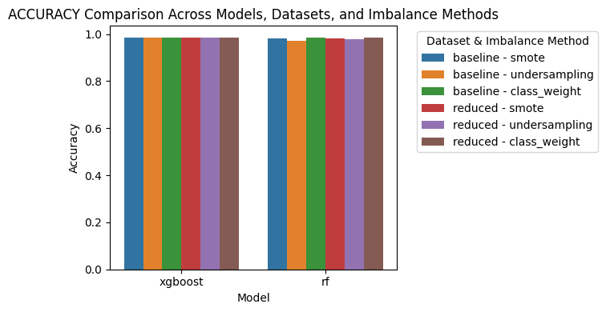

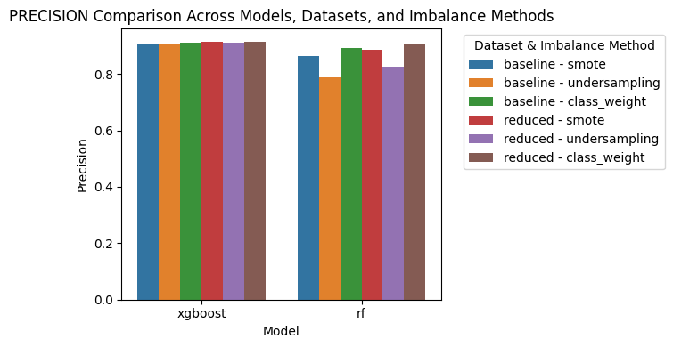

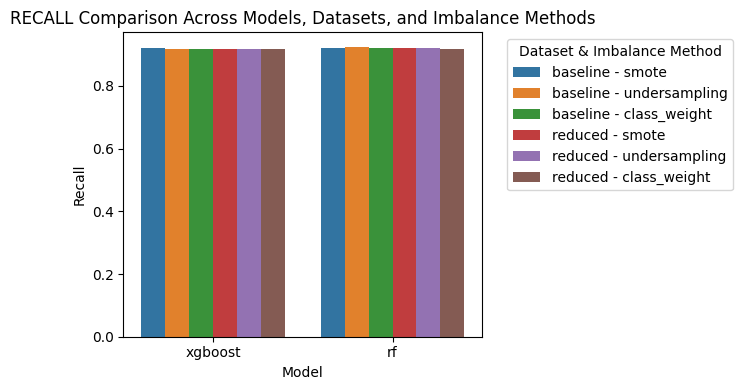

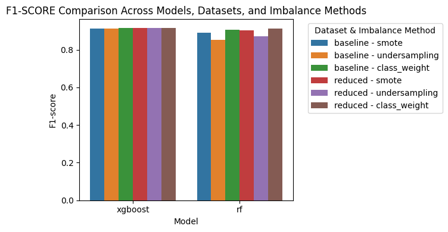

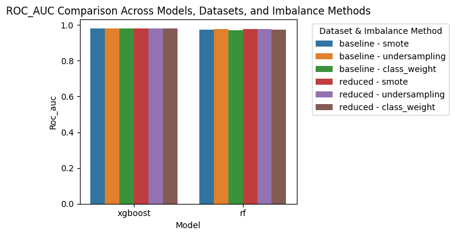

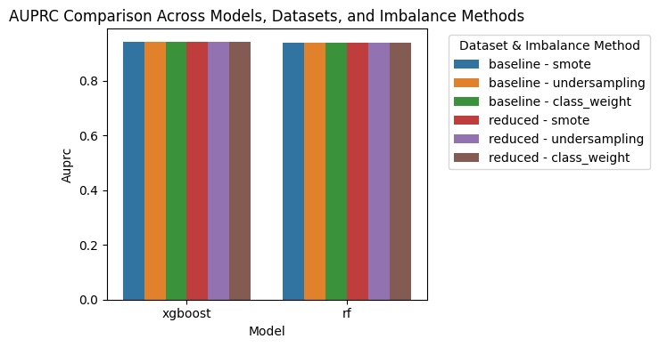

```python
# List of metrics you want to plot
metrics = ['accuracy', 'precision', 'recall', 'f1-score', 'roc_auc', 'auprc']

# Loop through each metric and call plot_results
for metric in metrics:
    plot_results(results, metric)
```

## **Optional: Feature Extraction (PCA)**

```python
from sklearn.model_selection import train_test_split

# train/test split
X_train_pca, X_test_pca, y_train_pca, y_test_pca  = train_test_split(X, y, test_size = 0.2, stratify=y, random_state = 42)
```

```python
from sklearn.preprocessing import StandardScaler
from sklearn.decomposition import PCA
from sklearn.model_selection import train_test_split

# train/test split
X_train, X_test, y_train, y_test = train_test_split(X, y, test_size=0.2, random_state=7, stratify=y)

# Standardize the data
scaler = StandardScaler()
X_train_scaled = scaler.fit_transform(X_train)
X_test_scaled = scaler.transform(X_test)

# Apply PCA on training data
pca = PCA()
X_train_pca = pca.fit_transform(X_train_scaled)

# Print the explained variance ratio
print(f"\033[1mProportion of variance explained by each principal component:\033[0m \n{pca.explained_variance_ratio_}")
```

```
Proportion of variance explained by each principal component:
[0.29563369 0.2095539  0.17848867 0.1388833  0.10250158 0.036019
 0.03215581 0.00676407]
```

```python
# Show transformed data
pc_columns = [f'PC{i+1}' for i in range(X_train.shape[1])]
pc_df = pd.DataFrame(X_train_pca, columns = pc_columns)
pc_df.head()
```

|  | PC1 | PC2 | PC3 | PC4 | PC5 | PC6 | PC7 | PC8 |
| --- | --- | --- | --- | --- | --- | --- | --- | --- |
| 0 | -0.19277542 | -0.34344230 | -1.24104127 | -1.00711863 | 1.42599884 | -0.28350065 | 0.05955016 | -0.13342428 |
| 1 | -0.20192954 | -0.29546009 | -0.71117905 | -0.48217136 | 0.81930187 | -0.62276244 | 0.14650846 | -0.07801961 |
| 2 | -0.46829425 | 0.91605678 | -0.33137588 | -0.69973515 | -1.57030841 | -0.36814023 | 0.05525066 | 0.02386093 |
| 3 | -0.48481028 | 0.94602767 | -0.26594766 | -0.78239246 | -1.54472345 | -0.43271514 | 0.09639967 | 0.03298899 |
| 4 | -0.07506769 | -0.16075004 | 0.09331027 | 0.34686389 | -0.03734210 | -1.07282088 | 0.21054023 | 0.00416852 |

```python
explained_variance = pca.explained_variance_ratio_
print("Sorted List returned :")
print(sorted(explained_variance,reverse = True))
```

```
Sorted List returned :
[0.29563368774986803, 0.2095538965518381, 0.17848866790960055, 0.13888329538308178, 0.10250157527470935, 0.03601899914540647, 0.032155807999587865, 0.006764069985907967]
```

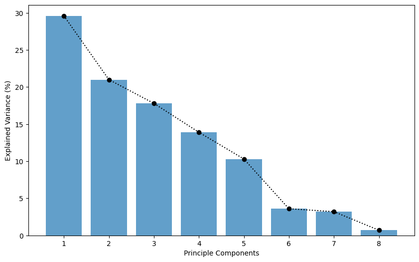

```python
import numpy as np

# Scree plot
var_pct = np.round(pca.explained_variance_ratio_ * 100, decimals = 1)

plt.figure(figsize=(10, 6))
plt.bar(range(1, len(var_pct) + 1), var_pct, alpha=0.7)
plt.plot(range(1, len(var_pct) + 1), var_pct, color='k', linestyle=':', marker='o')

plt.xticks(range(1, len(var_pct) + 1))
plt.xlabel('Principle Components')
plt.ylabel('Explained Variance (%)')

plt.show()
```

### Model Fitting (with PCA)

```python
from sklearn.metrics import precision_score, recall_score, f1_score, roc_auc_score, average_precision_score

# Apply PCA on test data
X_test_pca = pca.transform(X_test_scaled)

# Retrieve X at k=4 (80%)
k = 4
X_train_xgb = X_train_pca[:, :k]
X_test_xgb = X_test_pca[:, :k]

# Fit and transform y labels
encoder = LabelEncoder()
y_train_encoded = encoder.fit_transform(y_train)
y_test_encoded = encoder.transform(y_test)

# Train the model
xgb_pca = XGBClassifier(objective='binary:logistic', eval_metric='auc')
xgb_pca_model = xgb_pca.fit(X_train_xgb, y_train_encoded)

# Predict with test data
y_pred_xgb_pca = xgb_pca_model.predict(X_test_xgb)
y_pred_prob_xgb_pca = xgb_pca_model.predict_proba(X_test_xgb)[:, 1]  # Get predicted probabilities for ROC and AUPRC

# Calculate metrics
accuracy_xgb_pca = accuracy_score(y_test_encoded, y_pred_xgb_pca)
precision_xgb_pca = precision_score(y_test_encoded, y_pred_xgb_pca)
recall_xgb_pca = recall_score(y_test_encoded, y_pred_xgb_pca)
f1_xgb_pca = f1_score(y_test_encoded, y_pred_xgb_pca)
roc_auc_xgb_pca = roc_auc_score(y_test_encoded, y_pred_prob_xgb_pca)
auprc_xgb_pca = average_precision_score(y_test_encoded, y_pred_prob_xgb_pca)

# Print results
print(f'\033[1mXGBoost Performance with PCA\033[0m:')
print(f'Accuracy: {accuracy_xgb_pca:.6f}')
print(f'Precision: {precision_xgb_pca:.6f}')
print(f'Recall: {recall_xgb_pca:.6f}')
print(f'F1-score: {f1_xgb_pca:.6f}')
print(f'ROC AUC: {roc_auc_xgb_pca:.6f}')
print(f'AUPRC: {auprc_xgb_pca:.6f}')
```

```
XGBoost Performance with PCA:
Accuracy: 0.982972
Precision: 0.916936
Recall: 0.882900
F1-score: 0.899596
ROC AUC: 0.978388
AUPRC: 0.930863
```

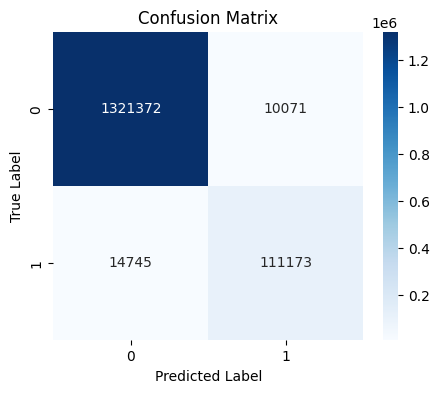

```python
from sklearn.metrics import confusion_matrix, roc_auc_score, roc_curve, auc
from sklearn.preprocessing import label_binarize

# Confusion Matrix
cm = confusion_matrix(y_test_encoded, y_pred_xgb_pca)

plt.figure(figsize=(5, 4))
sns.heatmap(cm, annot=True, fmt='d', cmap='Blues', xticklabels=encoder.classes_, yticklabels=encoder.classes_)
plt.title('Confusion Matrix')
plt.xlabel('Predicted Label')
plt.ylabel('True Label')
plt.show()
```

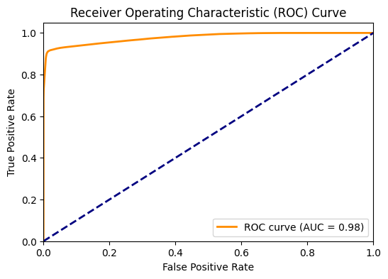

```python
import matplotlib.pyplot as plt
from sklearn.metrics import roc_curve, auc

# Get the predicted probabilities for the test data
y_pred_prob_xgb_pca = xgb_pca_model.predict_proba(X_test_xgb)[:, 1]

# Calculate the ROC curve
fpr, tpr, thresholds = roc_curve(y_test_encoded, y_pred_prob_xgb_pca)

# Calculate the AUC score
roc_auc = auc(fpr, tpr)

# Plot the ROC curve
plt.figure(figsize=(6, 4))
plt.plot(fpr, tpr, color='darkorange', lw=2, label=f'ROC curve (AUC = {roc_auc:.2f})')
plt.plot([0, 1], [0, 1], color='navy', lw=2, linestyle='--')
plt.xlim([0.0, 1.0])
plt.ylim([0.0, 1.05])
plt.xlabel('False Positive Rate')
plt.ylabel('True Positive Rate')
plt.title('Receiver Operating Characteristic (ROC) Curve')
plt.legend(loc='lower right')
plt.show()
```

### **Summary of Findings:** PCA vs. Univariate Feature Selection

**Pros & Cons of PCA:**

- **Advantages:** PCA is particularly beneficial in high-dimensional datasets, such as those in cybersecurity where there may be 100+ features. By reducing the number of dimensions while retaining the most significant variance, PCA can improve computational efficiency, decrease overfitting, and make it easier to identify underlying patterns. In cases where the data is noisy or contains redundant features, PCA can help in filtering out less informative components, enabling more effective model training and reducing processing time.
- **Disadvantages:** While PCA is powerful for dimensionality reduction, its primary drawback is the loss of interpretability. The principal components derived from PCA are linear combinations of the original features, which makes it difficult to understand the relationship between the new components and the original variables. In cybersecurity, where understanding and interpreting specific features (e.g., unusual network traffic patterns or specific attack vectors) is critical, PCA can obscure insights, making it harder to relate the results back to actionable security measures or specific threats. Additionally, important interactions or non-linear relationships between features might be missed in the transformation process.